# The AI Architect’s Handbook

Designing Intelligent Systems That Last

2026-09-04

First Edition · v1.2

> **The purpose of an AI Architect is to design systems that reliably create value under real-world constraints.**

## Connect the dots: decision models and delivery responsibility

Choose the mechanism for each decision: exact rules, a conventional classifier, a typed decision model, a generative model or human review. Preserve the existing inference contract, authority boundary and production gates. Jev and Laya are candidates to evaluate, not reasons to relax those controls.

Use Reasoning System Design for the canonical comparison and dated sources, and Production AI Assurance for calibration, selective coverage and rollout evidence.

A forward deployed architect carries these decisions into customer delivery. Compare architecture, engineering and outcome ownership, then use the same evidence packet through the engagement.

Understand → Build → Evaluate → Deliver: shared route · Build the comparison · Deliver the capstone

## How to use this handbook

This book teaches architectural judgment rather than framework memorisation. It is designed to be read in three ways:

1. **Sequentially** - for a complete architecture learning path.
2. **By problem** - use the reading paths and chapter relationships to move directly to evidence, evaluation, agents, security, governance, operations, privacy, or platform design.
3. **For review and interviews** - use the Field Guide, architecture smells, whiteboard challenges, and interview questions as practice material.

The recurring learning layers are:

- **Knowledge** - understand the architectural concept.
- **Engineering** - implement the mechanism reliably.
- **Judgment** - decide when the mechanism is appropriate and what trade-offs remain.

## Editorial conventions

- **Original synthesis** is labelled when the handbook introduces a new reasoning tool or framework.
- **References** use concise numbered sources. Detailed freshness notes live in the repository source register.
- **Current vendor and regulatory examples** illustrate architecture and may change. Enduring principles should survive those changes.
- **AI architecture extends software architecture**; it does not replace it.

## v1.2 Field Revision - Production Acceptance and Freshness

> **Audited 4 September 2026.** This revision preserves the accepted Chapters 0-13 and adds a production-acceptance operating model. Time-sensitive protocol, observability, platform, privacy, and regulatory statements were checked against primary sources. Example thresholds and scenario values remain illustrative; every production threshold must be derived from the workflow baseline, consequence, evidence, and business context.

### Six Production Gates

**Original synthesis.** A pilot is not production-ready because the model looks capable or a demonstration succeeds. A release or expansion decision should pass all six gates below. Any exception must name an accountable owner, compensating control, expiry date, and review trigger.

| Gate | Minimum evidence | If the gate fails |
| --- | --- | --- |
| **Value** | Measured improvement against the current workflow or a credible non-AI alternative. | Redesign the problem or stop. |
| **Quality** | System-level results meet risk- and segment-aware thresholds on representative tasks. | Restrict scope, improve the system, or return to evaluation. |
| **Safety** | Abuse, security, privacy, policy, and consequential-failure controls are tested; residual risks are accepted by the relevant owner. | Reduce authority or block release. |
| **Operability** | SLOs, telemetry, ownership, runbooks, recovery, rollback, and incident escalation work in the target environment. | Keep the system out of production influence. |
| **Economics** | Cost per successful outcome is viable at realistic volume, including review, retries, tools, observability, and failure handling. | Change the architecture, pricing, or scope. |
| **Adoption** | Representative users can use the workflow correctly, understand its limits, obtain support, and provide feedback; the operating owner accepts the change. | Improve the workflow and rollout design before scaling. |

#### Decision rule

> **Production readiness is the intersection of value, quality, safety, operability, economics, and adoption—not the average of them.**

### Progressive Rollout Ladder

Authority should increase only when evidence supports it. Promotion is a decision, not a calendar event.

| Stage | System authority | Evidence required to advance |
| --- | --- | --- |
| **Shadow** | Observe and generate outputs without influencing the live decision. | Representative coverage, failure visibility, and improvement over the baseline. |
| **Assist** | Offer suggestions; a user retains the action and decision. | Demonstrated usefulness, calibrated reliance, correction paths, and acceptable human factors. |
| **Supervised action** | Prepare or execute an action only after explicit approval at the consequence boundary. | Reliable authority checks, idempotency, audit, recovery, and bounded error impact. |
| **Bounded autonomy** | Act inside deterministic scope, spend, data, time, and reversibility limits. | Sustained production evidence, effective stop controls, and tested rollback or containment. |
| **Scale or expand** | Add cohorts, workflows, regions, or authority without weakening existing boundaries. | All six gates remain green under the new load and context. |

When evidence deteriorates, pause, narrow, or move down the ladder. Do not use sunk cost or executive enthusiasm as promotion evidence.

### Adoption Ownership and Rhythm

Adoption is an engineering and operating concern, not a communications activity at the end of delivery. Assign explicit responsibilities:

- **Workflow owner** — owns the business outcome, process change, and acceptance decision.
- **Representative users and champions** — test real work, expose friction, and model safe use for peers.
- **Product or field team** — owns discovery, configuration, feedback closure, and rollout evidence.
- **Platform and operations** — own shared runtime controls, reliability, support, and recovery.
- **Security, privacy, legal, safety, and risk specialists** — review when the system's data, authority, sector, or consequence requires them; no single title is a universal sign-off.
- **Executive sponsor** — resolves material cross-functional blockers and owns the investment decision where appropriate.

Use a cadence proportionate to risk: frequent evidence and user-friction reviews during limited rollout; an explicit review before each authority or cohort expansion; and a periodic operating review after scale. Each rhythm should end in a recorded **scale, hold, narrow, or stop** decision.

### Production Handoff Gate

Before the delivery team withdraws or ownership changes, verify:

- named product, workflow, technical, and incident owners;
- runbooks, escalation routes, service objectives, dashboards, and support coverage;
- access and credential transfer with least privilege and revocation of temporary access;
- a demonstrated stop, containment, rollback, or safe-degradation path;
- accepted evaluation, safety, economic, adoption, and residual-risk evidence;
- a backlog and owner for known limitations and newly discovered failures;
- a recorded acceptance decision and the conditions that trigger re-review.

### Freshness Register — 4 September 2026

[output not shown]

**Freshness rule:** re-check protocol, model/platform, security, legal, and standards claims before a production decision and during the quarterly handbook freshness audit. Enduring architecture principles do not remove the need to verify the current mechanism.

## The four-part reading structure

### Part I - Architectural Judgment

Chapters 0-3 establish how architects reason about uncertainty, decisions, and quality.

### Part II - Evidence, Intelligence, and Evaluation

Chapters 4-6 explain how evidence, evaluation, models, and inference combine to produce credible system behaviour.

### Part III - Controlled Agency

Chapters 7-11 cover stateful action, security, governance, operations, data, and privacy.

### Part IV - Enterprise Scale and Synthesis

Chapters 12-13 move from individual systems to shared platforms and comparative reference architectures.

## A note on legal, security, and operational guidance

This handbook is architecture guidance, not legal advice or a substitute for specialist security, privacy, safety, or sector-specific review. Current legal and standards examples should be verified in the relevant jurisdiction and operating context.

# Part I - Architectural Judgment

> **Architecture is the discipline of making consequential decisions explicit, testable, and revisable. AI adds uncertainty to those decisions; it does not remove the need for engineering discipline.**

This part establishes the reasoning foundation: architectural judgment, the transition from software to AI architecture, the anatomy of an AI decision, and quality attributes expressed as measurable scenarios.

# Chapter 0 - How to Think Like an AI Architect

*Judgment, uncertainty, and decisions that survive change*

**Related chapters:** Chapters 1, 2, 3, and 13

> **The distinguishing skill of an AI Architect is not knowing more models. It is making better decisions about where intelligence belongs, what evidence is required, how uncertainty is controlled, and whether the resulting system creates durable value.**

## 1. Why Begin with Thinking?

A handbook about AI architecture could begin with transformers, embeddings, retrieval, agents, or cloud platforms.

This one begins with judgment.

Technologies change faster than the responsibilities of an architect. Models improve, frameworks are replaced, terminology shifts, and implementation patterns mature. Yet the enduring questions remain recognisable:

- What outcome must the system produce?
- Which quality attributes matter most?
- Where can uncertainty create value?
- Where would uncertainty create unacceptable risk?
- What trade-offs are being made?
- What evidence supports the decision?
- How will the system behave when assumptions fail?
- Who remains accountable?
- How will the architecture adapt?

Software architecture has long connected business and mission goals to quality attributes and design decisions. The Software Engineering Institute’s Quality Attribute Workshop derives architecture-critical qualities from stakeholder goals, while the Architecture Tradeoff Analysis Method evaluates how architectural decisions support—or endanger—those goals.[1][2] ISO/IEC/IEEE 42010 distinguishes an architecture from the descriptions used to communicate it and formalises concepts such as viewpoints and model kinds.[3]

AI does not invalidate this foundation. It enlarges the decision space.

Current AI workload guidance identifies nondeterministic functionality, data and application design, and operations as architectural concerns. NIST treats AI risk management as a continuous lifecycle activity organised around governance, contextual mapping, measurement, and management.[4][5]

An AI Architect therefore needs the habits of a software architect, systems thinker, risk manager, product strategist, and technical leader. The role requires enough implementation knowledge to challenge assumptions, but its highest-value contribution is not typing the most code.

It is improving the quality of consequential decisions.

## 2. Learning Objectives

By the end of this chapter, you should be able to:

- explain why architectural judgment matters more than familiarity with a particular AI framework;
- translate business and mission goals into architecture-significant questions;
- distinguish capability, evidence, confidence, value, and autonomy;
- identify deterministic, probabilistic, and governed boundaries;
- reason explicitly about assumptions, trade-offs, failure modes, and reversibility;
- decide when AI is inappropriate;
- use the Architect’s Loop to make and revisit decisions;
- communicate uncertainty without becoming vague or indecisive;
- evaluate an AI proposal using the AI Trust Triangle;
- recognise common thinking errors in AI architecture interviews and design reviews.

## Part I — The Architect’s Real Product

### 3. Architects Produce Decisions

Architecture is often represented by diagrams.

Diagrams matter. They help stakeholders understand structures, boundaries, interactions, deployment topologies, data flows, and responsibilities. The current ISO architecture-description standard explicitly supports viewpoints and model kinds because different concerns require different representations.[3]

But a diagram is not the architecture.

A diagram records or communicates decisions such as:

- where responsibilities are placed;
- which dependencies are accepted;
- how state is managed;
- which trust boundaries exist;
- what quality attributes receive priority;
- how failures are contained;
- where change is expected;
- what has deliberately been excluded.

The architect’s primary product is therefore a set of **explainable, testable, and revisable decisions**.

A strong decision contains at least five elements:

1. **Context** — What problem and constraints are present?
2. **Options** — Which credible alternatives were considered?
3. **Decision** — What has been chosen?
4. **Consequences** — What improves, what worsens, and what risk remains?
5. **Validation** — What evidence will show whether the decision was sound?

Microsoft’s current architect-role guidance similarly emphasises business alignment, documented trade-offs, architecture decision records, validation of critical assumptions, lifecycle collaboration, supportability, and design for change.[6]

#### Architectural principle — Decisions over diagrams

> **A diagram becomes architecture only when it communicates decisions, responsibilities, constraints, and consequences.**

This is an original synthesis used throughout this handbook. It does not claim that diagrams are unimportant. It clarifies what gives them architectural meaning.

### 4. The Progression from Engineer to Architect

The transition to architecture is sometimes misunderstood as a move away from technical depth.

It is better understood as an expansion of scope.

#### Engineers optimise components

They ask:

- Is the implementation correct?
- Is the API efficient?
- Does the service pass its tests?
- Can the query be improved?
- Is the model prompt producing the intended output?

#### Senior engineers optimise systems

They ask:

- How do components interact?
- Where are the bottlenecks?
- What happens during partial failure?
- How is the system deployed and operated?
- How do local changes affect global behaviour?

#### Architects optimise decisions

They ask:

- Are we solving the right problem?
- Which qualities matter most?
- Which assumptions are dangerous?
- Is the added complexity justified?
- What will become difficult to change?
- Can stakeholders understand the consequences?
- How will this architecture remain viable as the organisation evolves?

This gives us one of the handbook’s working propositions:

> **Junior engineers often optimise components. Senior engineers optimise systems. Architects optimise decisions.**

The proposition is intentionally directional rather than absolute. Architects still need technical fluency, and engineers at every level make architectural decisions. The point is that the architect is accountable for the coherence and consequences of decisions across the wider system.

## Part II — Begin with Value, Not AI

### 5. The Wrong First Question

The most common weak opening in an AI initiative is:

> Which model should we use?

It is weak because it assumes that:

- the problem is understood;
- AI is appropriate;
- a model is the principal constraint;
- the desired behaviour can be evaluated;
- the organisation can operate the resulting system;
- the expected value justifies the cost and risk.

A better opening sequence is:

```
Business or Mission Goal
          │
          ▼
Required Outcome
          │
          ▼
User and Stakeholder Need
          │
          ▼
Quality and Risk Constraints
          │
          ▼
Decision or Workflow to Improve
          │
          ▼
Is AI Appropriate?
          │
          ▼
Architecture Options
```

The sequence reflects established architecture practice: business and mission goals inform quality attributes, which in turn influence architecture decisions.[1][2]

#### The AI value test

Before proposing a model, ask:

1. **What decision, task, or outcome improves?**
2. **Who benefits, and how will the benefit be observed?**
3. **Why are rules, search, analytics, workflow automation, or conventional software insufficient?**
4. **Does probabilistic interpretation create genuine value?**
5. **What is the cost of an incorrect output?**
6. **Can the workflow tolerate or recover from that error?**
7. **What evidence is available for evaluation?**
8. **What operating capability is required after launch?**

AI may be appropriate when a task involves ambiguity, language, perception, semantic matching, open-ended generation, pattern recognition, or reasoning that would be impractical to encode completely as rules.

AI may be inappropriate when:

- the rule is known and stable;
- correctness must be exact;
- the required information is already structured;
- the decision is simple enough for deterministic logic;
- representative evaluation is impossible;
- the organisation cannot govern the consequences;
- the expected value does not justify operational complexity.

#### Architect’s Notebook

> **The decision not to use AI can be an AI Architect’s most valuable contribution.**

Refusing unnecessary AI is not resistance to innovation. It is the disciplined avoidance of complexity that has not earned its place.

### 6. From Capability to Outcome

AI initiatives often measure what is easy rather than what matters.

Model-oriented measures include:

- benchmark score;
- answer similarity;
- token throughput;
- context-window size;
- model parameter count.

These may inform design, but they are not the same as business outcome.

For example, a customer-service assistant can improve its answer-quality score while increasing handling time because users repeatedly ask for clarification. A code assistant can produce more accepted suggestions while increasing review burden. An incident agent can identify technically plausible causes while delaying restoration by recommending the wrong first action.

A useful outcome chain is:

```
Model Capability
       │
       ▼
Task Performance
       │
       ▼
Workflow Behaviour
       │
       ▼
User or Operator Decision
       │
       ▼
Operational Outcome
       │
       ▼
Business or Mission Value
```

Each arrow contains assumptions.

The architect’s job is to make those assumptions visible and test them.

#### Architectural smell — Benchmark substitution

> A public benchmark is used as a substitute for evidence that the proposed system will improve the organisation’s task or outcome.

Public benchmarks can support initial model selection. They cannot establish production fitness for a specific workflow, population, risk level, or operating environment.

## Part III — Architecture as the Management of Uncertainty

### 7. Complexity and Uncertainty

Traditional software architecture already manages uncertainty:

- incomplete requirements;
- uncertain load;
- changing business needs;
- unreliable networks;
- human error;
- dependency failure;
- evolving regulation.

AI adds uncertainty **inside the behaviour-producing mechanism**.

The output may depend on:

- learned model behaviour;
- prompt wording;
- context selection;
- retrieval results;
- tool responses;
- sampling;
- model-provider changes;
- user language;
- data distribution;
- safety policies.

The architect is not expected to eliminate all uncertainty. Elimination would often remove the flexibility that makes AI valuable.

The task is to decide:

- where uncertainty is useful;
- where it is acceptable;
- where it must be constrained;
- where it requires evidence;
- where a human must retain authority;
- how uncertainty will be observed;
- how the system will recover when it becomes harmful.

#### Core philosophy

> **Software architecture manages complexity. AI architecture manages complexity and uncertainty.**

This is the handbook’s original synthesis. It does not imply that traditional software is free from uncertainty. It highlights that AI places probabilistic behaviour within the runtime decision path and therefore requires additional architectural treatment.

### 8. The Uncertainty Boundary

Every AI system should make its uncertainty boundary visible.

#### Deterministic zone

Use explicit mechanisms for:

- authentication;
- authorisation;
- financial limits;
- policy enforcement;
- schema validation;
- state transitions;
- audit;
- irreversible execution.

#### Probabilistic zone

Use AI where interpretation or generation provides value:

- summarisation;
- classification;
- semantic retrieval;
- extraction from ambiguous content;
- recommendation;
- drafting;
- planning proposals.

#### Governed transition

Use validation, policy, evidence, approvals, and constrained interfaces where probabilistic output can alter business state.

```
Probabilistic Interpretation
            │
            ▼
 Evidence + Validation + Policy
            │
            ▼
   Deterministic Execution
```

The governed transition may include:

- output schemas;
- allowed-value checks;
- retrieval provenance;
- policy engines;
- risk thresholds;
- human approval;
- idempotency controls;
- transactional boundaries;
- rollback or compensation.

#### Architectural principle — Consequence determines control

> **The required control should be proportional to the consequence of an incorrect AI output, not merely to the apparent sophistication of the model.**

A model drafting a meeting summary and the same model initiating a bank transfer create radically different architectural obligations.

## Part IV — The AI Trust Triangle

### 9. Three Questions of Trust

The AI Trust Triangle is a recurring diagnostic tool:

```
                Capability
                     ▲
                    / \
                   /   \
                  /     \
        Confidence ----- Evidence
```

#### Capability

Can the system perform the task at the required level?

Capability includes more than the base model. It may depend on:

- task decomposition;
- context construction;
- retrieval;
- tools;
- memory;
- deterministic computation;
- routing;
- interface design.

#### Evidence

What grounds, verifies, or constrains the result?

Evidence may include:

- source documents;
- database records;
- tool responses;
- calculations;
- policy rules;
- provenance;
- test results;
- human input.

#### Confidence

What level of reliance is justified?

Confidence is a system-level judgement informed by:

- representative evaluation;
- evidence quality;
- deterministic validation;
- historical performance;
- task risk;
- policy compliance;
- human review;
- known limitations.

It is **not** simply a confidence percentage generated by the model.

NIST’s AI RMF reinforces the broader point that trustworthiness must be managed through contextual mapping, measurement, governance, and risk treatment rather than assumed from system output.[4]

### 10. The Triangle as a Diagnostic Tool

The Triangle is useful only if it changes action.

#### Capability is weakest

Symptoms:

- poor reasoning;
- incorrect tool choice;
- weak synthesis;
- failure on domain language;
- inability to follow complex instructions.

Possible responses:

- simplify the task;
- improve decomposition;
- add deterministic computation;
- improve tool descriptions;
- use selective model escalation;
- fine-tune only when evidence supports the need.

#### Evidence is weakest

Symptoms:

- plausible but unsupported answers;
- stale knowledge;
- incorrect citations;
- confident responses despite missing information;
- actions based on unverified user claims.

Possible responses:

- improve retrieval recall and ranking;
- add authoritative tools;
- capture provenance;
- expose evidence to users;
- refuse or escalate when evidence is insufficient.

#### Confidence is weakest

Symptoms:

- good demos but no representative evaluation;
- no acceptance threshold;
- unknown performance across user groups or edge cases;
- uncontrolled expansion into higher-risk workflows.

Possible responses:

- build an evaluation set;
- segment results by risk and task;
- add production feedback;
- define escalation rules;
- limit autonomy;
- make residual uncertainty explicit.

#### The diagnostic question

> **Which corner is weakest, and what happens if it fails?**

The second half matters. A weak evidence path in a brainstorming assistant has different consequences from a weak evidence path in clinical or financial decision support.

### 11. Boundaries of the Triangle

The AI Trust Triangle is not a complete architecture framework.

It does not independently cover:

- business value;
- total cost;
- latency;
- security;
- privacy;
- fairness;
- resilience;
- sustainability;
- legal obligations;
- organisational readiness.

It should be used alongside broader quality-attribute analysis and risk management. Well-Architected frameworks deliberately require architects to balance multiple pillars and trade-offs rather than optimise a single dimension.[5][7]

The Triangle is therefore a **focused thinking tool for justified reliance**.

It earns its place when it helps a team diagnose why an apparently intelligent system should—or should not—be trusted for a particular task.

## Part V — The Architect’s Loop

### 12. A Repeatable Way to Think

Architecture is not a one-time act performed before implementation.

It is a learning loop.

```
Observe
   ↓
Understand
   ↓
Question
   ↓
Model
   ↓
Evaluate
   ↓
Decide
   ↓
Validate
   ↓
Observe Again
```

#### Observe

Gather evidence from:

- users;
- business processes;
- incidents;
- logs;
- evaluations;
- costs;
- support teams;
- regulatory context;
- system behaviour.

Do not begin by defending a preferred solution.

#### Understand

Clarify:

- the problem;
- stakeholders;
- desired outcomes;
- constraints;
- quality attributes;
- current workflow;
- sources of uncertainty;
- consequences of failure.

#### Question

Challenge the framing:

- Is the stated problem the real problem?
- Is AI necessary?
- Which assumptions are untested?
- Is a local optimisation damaging the system?
- What would a sceptical stakeholder ask?

#### Model

Represent the problem using:

- context and container diagrams;
- data and evidence flows;
- sequence diagrams;
- threat models;
- quality-attribute scenarios;
- risk models;
- decision tables;
- cost models;
- prototypes.

ISO/IEC/IEEE 42010’s emphasis on viewpoints is useful here: different stakeholders and concerns require different architectural representations.[3]

#### Evaluate

Compare credible alternatives against:

- business goals;
- quality attributes;
- risk;
- cost;
- reversibility;
- operating capability;
- time;
- evidence.

The SEI’s ATAM provides an established example of evaluating decisions, sensitivity points, risks, and trade-offs relative to business drivers.[2]

#### Decide

Document:

- what was selected;
- what was rejected;
- why;
- under which assumptions;
- with which consequences;
- when the decision should be revisited.

#### Validate

Use the lightest method capable of reducing the important uncertainty:

- proof of concept;
- benchmark;
- load test;
- evaluation set;
- shadow deployment;
- red-team exercise;
- user study;
- architecture review;
- controlled production experiment.

#### Observe again

Production changes understanding.

NIST explicitly describes AI risk management as continuous across the lifecycle, while current generative-AI operational guidance recommends observing layers from models through user interactions and using those measurements to improve system behaviour.[4][8]

The loop therefore never truly closes.

## Part VI — The Five Questions

### 13. Questions That Outlive Frameworks

Whenever you encounter a new model, framework, pattern, or architecture proposal, ask:

#### 1. What problem does this solve?

A feature list is not a problem statement.

Look for the user, workflow, constraint, or quality attribute that justifies the component.

#### 2. What assumptions does it make?

Examples:

- the model provider remains available;
- retrieved documents are trustworthy;
- latency remains within budget;
- users provide sufficient context;
- tools return current data;
- a judge model correlates with human assessment;
- the organisation can support the operational burden.

Hidden assumptions become future incidents.

#### 3. What trade-off does it introduce?

Every decision optimises something.

Ask what becomes:

- slower;
- more expensive;
- more coupled;
- harder to observe;
- harder to secure;
- less portable;
- less predictable;
- more dependent on human review.

Trade-offs are central to architecture evaluation, not signs of a poor decision.[2]

#### 4. How does it fail?

Study:

- ordinary failure;
- partial failure;
- silent degradation;
- misuse;
- malicious input;
- dependency change;
- cost runaway;
- organisational failure.

A successful demo reveals capability. Failure analysis reveals architecture.

#### 5. How will we know it is working?

Define:

- technical metrics;
- task metrics;
- safety metrics;
- workflow outcomes;
- business outcomes;
- acceptance thresholds;
- review cadence;
- decision owners.

If the team cannot define evidence of success, it is not ready to automate the decision.

## Part VII — Thinking in Trade-offs

### 14. There Is No Best Architecture

Architecture is contextual.

A design that is excellent for one organisation may be inappropriate for another because of differences in:

- risk tolerance;
- data sensitivity;
- latency;
- scale;
- team capability;
- regulation;
- budget;
- change rate;
- vendor strategy;
- operational maturity.

Established architecture methods treat quality attributes as interacting goals. Improving one can weaken another, and the chosen balance must reflect business drivers.[2]

AI adds further tensions:

| Decision | Likely benefit | Likely cost or risk |
| --- | --- | --- |
| Larger model | Greater capability on some tasks | Higher cost, latency, and dependency |
| Longer context | More information available | More tokens, noise, and context-management complexity |
| Retrieval | Fresher and attributable knowledge | Indexing, ranking, access-control, and evaluation burden |
| Fine-tuning | More specialised behaviour | Data, training, validation, and model-lifecycle overhead |
| Multi-agent design | Role separation and parallelism | Coordination, observability, and failure complexity |
| Human approval | Reduced consequence of error | Slower workflow and review cost |
| Strong abstraction | Portability and replaceability | Lowest-common-denominator design or adapter overhead |
| Aggressive autonomy | Faster execution | Larger blast radius and governance burden |

The mature answer is rarely “always use” or “never use.”

It is:

> **Use this option under these conditions, because these benefits outweigh these costs, and revisit the decision when these assumptions change.**

### 15. Reversibility and the Cost of Being Wrong

Not all decisions deserve equal analysis.

Ask two questions:

1. **How consequential is the decision?**
2. **How difficult is it to reverse?**

A low-consequence, reversible experiment can move quickly.

A high-consequence, difficult-to-reverse decision requires stronger evidence, broader review, and explicit risk ownership.

Examples of difficult-to-reverse decisions include:

- embedding provider-specific semantics throughout business logic;
- allowing agents direct privileged access;
- storing sensitive prompts without a retention design;
- using proprietary features that shape all evaluation and observability data;
- building a platform before proving repeated use cases;
- automating regulated decisions before establishing audit and appeal.

#### Architectural principle — Match evidence to irreversibility

> **The harder a decision is to reverse, the stronger the evidence and review required before committing to it.**

This principle applies beyond AI, but AI’s rapid evolution makes it especially important. Designing for change does not mean abstracting everything. It means identifying likely change points and avoiding unnecessary commitment at those boundaries.

## Part VIII — Failure as a Design Input

### 16. Assume the System Will Be Wrong

Traditional software can fail through defects, resource exhaustion, misconfiguration, dependency failure, or invalid input.

AI systems add failures such as:

- hallucinated facts;
- incorrect classifications;
- unsupported reasoning;
- wrong tool selection;
- stale retrieval;
- prompt injection;
- context contamination;
- policy evasion;
- model regression;
- evaluation blind spots;
- excessive autonomy.

The goal is not to make a promise of zero failure.

The goal is to design a response:

- detect;
- contain;
- explain;
- recover;
- learn.

#### Failure-design questions

- Can the system recognise insufficient evidence?
- Can an output be challenged?
- Can a user inspect the source?
- Can an action be reversed?
- Is the blast radius bounded?
- Does a human have meaningful intervention time?
- Can an incident be reconstructed?
- Will the same failure be added to regression evaluation?
- Can the system degrade to a safer mode?

#### Architecture smell — Happy-path intelligence

> The design demonstrates what the model can do but not what the system does when the model is wrong, unavailable, manipulated, or uncertain.

Microsoft’s architect-role guidance explicitly advises designing for operational reality and supportability rather than only for the happy path.[6]

### 17. Graceful Degradation

An AI system should not have only two states:

- fully intelligent;
- completely unavailable.

Possible degraded modes include:

- search without generation;
- deterministic workflow without recommendation;
- smaller or alternate model;
- read-only operation;
- reduced tool permissions;
- manual approval;
- delayed asynchronous processing;
- explicit “insufficient evidence” response;
- escalation to a human.

The correct degraded mode depends on the task.

A slower but accurate response may be appropriate for compliance review. A fast, limited response may be better for an interactive assistant. A safety workflow may need to stop rather than continue with reduced capability.

Architecture turns model failure into a system-level choice.

## Part IX — Evidence Before Confidence

### 18. Design for Reconstruction

A trustworthy AI system should support the question:

> Why did the system produce or take this result?

The answer may require:

- model and configuration version;
- prompt or policy version;
- retrieved sources and ranking;
- tool calls and responses;
- intermediate state;
- validation outcomes;
- approval decisions;
- identity and permissions;
- timestamps;
- final output;
- feedback or appeal.

This does not mean storing every hidden internal detail indefinitely. Retention, privacy, security, and cost still apply.

It means designing sufficient traceability for the risk and operational need.

AWS’s current operational guidance recommends comprehensive observability across the generative-AI system, including models, user interactions, feedback, functional performance, prompt templates, controls, and workflow tracing.[8]

#### Architectural principle — Design for evidence

> **An AI output should not appear as an unexplained event when it influences a consequential decision.**

### 19. Confidence Must Be Earned

A fluent output can create an illusion of certainty.

The architect must separate:

- **linguistic confidence** — how decisive the response sounds;
- **model probability** — where meaningful and available;
- **empirical reliability** — measured performance on representative cases;
- **decision confidence** — the justified level of reliance given evidence and consequence.

A system may sound uncertain and still be correct. It may sound authoritative and be wrong.

Confidence should therefore be based on external evidence such as:

- validated source coverage;
- deterministic checks;
- agreement with trusted systems;
- evaluation performance;
- production outcomes;
- risk category;
- human verification.

#### Architecture smell — Confidence theatre

> The interface displays a confidence value without demonstrating that the value is calibrated, task-specific, or useful for deciding whether to rely on the output.

## Part X — Autonomy and Accountability

### 20. The Principle of Earned Autonomy

Automation exists on a continuum:

```
Information
    ↓
Recommendation
    ↓
Assisted Action
    ↓
Supervised Automation
    ↓
Conditional Autonomy
    ↓
Broad Autonomy
```

Each step increases authority and potential consequence.

The handbook therefore adopts:

> **An AI system should never receive more autonomy than its evidence, evaluation, observability, governance, and recovery mechanisms can support.**

Autonomy is earned through demonstrated performance and operating maturity. It is not unlocked merely because a model can call tools.

Before increasing autonomy, assess:

- task success by scenario;
- severity and distribution of failures;
- evidence quality;
- policy compliance;
- tool-call correctness;
- resistance to manipulation;
- identity and least privilege;
- auditability;
- rollback;
- incident response;
- human intervention;
- accountability.

NIST places governance across the AI lifecycle and stresses multidisciplinary perspectives for surfacing assumptions and emergent risk.[4]

### 21. Human in the Loop Is Not a Complete Design

“Add human approval” is often proposed as a universal safeguard.

It is not sufficient unless the design answers:

- Which actions require approval?
- What evidence does the reviewer receive?
- How much time is available?
- Can the reviewer realistically detect the error?
- What happens when approval volume grows?
- Does repeated approval create automation bias?
- Who is accountable for the final action?
- Can the reviewer reject, edit, or escalate?
- Is the review logged?
- How are disagreements analysed?

A human who sees only the model’s recommendation may simply inherit the model’s error.

Meaningful oversight requires context, authority, time, and a usable intervention path.

## Part XI — Simplicity, Boundaries, and Change

### 22. Every Component Must Earn Its Place

A new component creates:

- another dependency;
- another failure mode;
- another security surface;
- another ownership question;
- another upgrade path;
- another source of cost;
- another concept engineers must understand.

This is **architectural gravity**.

Vector stores, agent supervisors, memory services, model gateways, evaluation platforms, and orchestration frameworks can all be valuable. None are free.

Ask:

- What problem does this component solve?
- Is the problem present now?
- Can the same outcome be achieved more simply?
- Who operates it?
- How is it tested?
- What happens when it is unavailable?
- How would it be replaced?

#### Architecture smell — Framework-shaped architecture

> The system’s boundaries mirror the chosen framework rather than the business capabilities, quality attributes, and operational responsibilities.

Frameworks should implement architecture, not define its purpose.

### 23. Design for Change Without Abstracting Everything

“Design for change” can produce excessive indirection when interpreted badly.

The goal is not to make every component replaceable at equal cost.

The goal is to identify likely change:

- model providers;
- prompt and policy versions;
- retrieval strategies;
- knowledge sources;
- tool interfaces;
- evaluation criteria;
- regulation;
- scale;
- organisational ownership.

Then create appropriate boundaries.

Examples:

- keep business rules outside model prompts;
- use explicit tool contracts;
- maintain representative evaluations independent of providers;
- capture provider-neutral operational events;
- separate knowledge ingestion from answer generation;
- version prompts, policies, models, and indexes;
- record assumptions in ADRs.

Microsoft’s current architect guidance explicitly recommends designing for evolution while setting practical bounds rather than attempting unlimited future-proofing.[6]

#### Architectural principle — Stable core, replaceable edge

> **Keep business intent, policy, evidence requirements, and evaluation stable enough to govern the system; allow models and implementation mechanisms to evolve behind explicit boundaries.**

## Part XII — Communicating Like an Architect

### 24. Make Uncertainty Legible

Architects are often expected to speak with confidence.

That does not require pretending certainty.

A strong architectural recommendation can say:

- what is known;
- what is assumed;
- what remains uncertain;
- why the proposed option is preferred;
- what evidence would change the decision;
- what risk is accepted;
- who accepts it;
- when the decision will be revisited.

Weak communication hides uncertainty.

Equally weak communication lists every possibility without making a recommendation.

The architect’s task is to convert incomplete information into a responsible decision, not to wait for perfect knowledge.

### 25. Explain Trade-offs to Different Stakeholders

#### To an executive

Focus on:

- outcome;
- cost;
- exposure;
- time;
- reversibility;
- decision required.

#### To engineering

Focus on:

- boundaries;
- quality attributes;
- failure modes;
- integration;
- operational ownership;
- validation.

#### To security and risk

Focus on:

- data;
- identity;
- permissions;
- threat paths;
- audit;
- residual risk;
- response.

#### To users and operators

Focus on:

- expected behaviour;
- limitations;
- evidence;
- escalation;
- support;
- feedback.

Architecture descriptions use viewpoints precisely because no single representation serves every stakeholder concern.[3]

### 26. Architecture Decision Records

An ADR should capture:

- context;
- decision drivers;
- options;
- decision;
- consequences;
- validation;
- revisit triggers.

For an AI decision, also capture:

- task and risk category;
- evidence sources;
- evaluation strategy;
- model and provider assumptions;
- deterministic boundaries;
- autonomy level;
- monitoring and rollback.

An ADR is not proof that a decision is correct.

It is evidence that the decision was made consciously and can be revisited when assumptions change.

## Part XIII — Architecture Smells

### 27. The Bigger Model Fix

**Symptom:** Every quality problem leads to a larger or more expensive model.

**Likely neglected causes:**

- poor retrieval;
- ambiguous task;
- missing tools;
- weak context;
- inadequate validation;
- bad user experience;
- absent evaluation.

**Question:** What evidence shows capability is the limiting factor?

### 28. AI Everywhere

**Symptom:** AI is inserted into rules, calculations, permissions, and workflow steps that deterministic software handles more reliably.

**Question:** Where does probabilistic behaviour genuinely create value?

### 29. Prompt as Policy

**Symptom:** Security, financial, legal, or compliance constraints exist only as natural-language instructions to the model.

**Question:** Which rules require deterministic enforcement outside the model?

### 30. Evaluation as an Afterthought

**Symptom:** The team relies on demonstrations and anecdotal feedback.

**Question:** Which representative cases and acceptance thresholds determine production fitness?

### 31. Invisible Cost

**Symptom:** Token spending is visible, but retrieval, evaluation, human review, support, and incident costs are ignored.

**Question:** What is the total cost of achieving the required outcome?

### 32. Autonomy by Demo

**Symptom:** A successful tool-calling demonstration is treated as evidence that the system can act independently in production.

**Question:** What evidence, controls, rollback, and accountability support the proposed autonomy?

### 33. Architecture by Vocabulary

**Symptom:** A proposal contains terms such as agents, memory, GraphRAG, reflection, and multi-agent orchestration but cannot explain the business problem or quality attributes.

**Question:** Which decision becomes better because each component exists?

## Part XIV — A Worked Scenario

### 34. “Build an AI Customer-Support Agent”

A business leader asks for an autonomous support agent to reduce cost.

#### Model-first response

- choose a frontier model;
- connect company documents;
- build tools for refunds and account changes;
- add an orchestration framework;
- launch a pilot.

#### Architectural response

##### Step 1 — Understand the outcome

- Is the goal lower cost, faster resolution, higher satisfaction, or twenty-four-hour coverage?
- Which request categories consume the most effort?
- Where do users currently fail?

##### Step 2 — Segment the work

- deterministic FAQs;
- knowledge lookup;
- policy interpretation;
- account-specific diagnosis;
- reversible actions;
- irreversible or regulated actions;
- emotional or exceptional cases.

##### Step 3 — Identify uncertainty boundaries

- AI may interpret intent and draft responses.
- Retrieval supplies current policy.
- Deterministic services verify identity and eligibility.
- High-risk actions require approval.
- Tool permissions are task-scoped.

##### Step 4 — Apply the Trust Triangle

**Capability:** Can the system understand the actual request distribution?

**Evidence:** Can answers and actions be traced to policy, account data, and tool results?

**Confidence:** What evaluation and operating evidence justifies reliance for each request category?

##### Step 5 — Define success

- containment rate without repeat contact;
- correct resolution;
- escalation quality;
- policy compliance;
- customer effort;
- action error rate;
- latency;
- cost per resolved request.

##### Step 6 — Design for failure

- insufficient evidence;
- conflicting policies;
- identity uncertainty;
- tool outage;
- malicious content;
- emotional or vulnerable customer;
- refund above threshold;
- model unavailability.

##### Step 7 — Earn autonomy

Begin with information and draft assistance. Expand to low-risk actions only after representative evaluation and production observation demonstrate that the controls are effective.

The difference between the two responses is not reluctance to build.

It is the conversion of an exciting capability into a governed system.

## Part XV — Interview Preparation

### 35. Foundational Questions

#### Question 1

**What is the most important skill of an AI Architect?**

A strong answer emphasises judgment: translating business goals and quality attributes into decisions about boundaries, evidence, risk, and operations.

A weak answer lists models, frameworks, or cloud services.

#### Question 2

**When is AI the wrong solution?**

Discuss known rules, exact correctness, structured data, low ambiguity, unacceptable error, inability to evaluate, weak value, and insufficient governance.

#### Question 3

**How do you decide what should be deterministic?**

Look for enforcement, irreversible state changes, security boundaries, financial constraints, policy, exact calculation, and audit.

Use AI for interpretation or proposals where uncertainty creates value.

#### Question 4

**How do you make an architectural decision with incomplete information?**

Describe assumptions, alternatives, consequence, reversibility, targeted validation, documented risk, and revisit triggers.

#### Question 5

**Why are trade-offs central to architecture?**

Quality attributes interact. Improving reliability, security, performance, cost, modifiability, or capability can weaken another concern. The architect chooses a context-appropriate balance and makes the consequences explicit.

### 36. Senior and Principal Questions

#### Question 6

**A stakeholder insists on using the strongest available model. How do you respond?**

Start with task and outcome. Determine whether capability is actually limiting. Compare cost, latency, evidence, privacy, operating risk, and fallback. Use evaluation to support routing or selective escalation rather than ideology.

#### Question 7

**How would you challenge an architecture that uses multiple agents?**

Ask:

- What independent responsibilities exist?
- Why cannot a deterministic workflow or single orchestrator handle them?
- What coordination state is required?
- How are loops and duplicate actions prevented?
- How is each contribution evaluated and traced?
- What complexity is added?

#### Question 8

**How do you communicate uncertainty without undermining confidence in the design?**

Separate known facts, assumptions, unresolved risks, and validation plans. Recommend a course of action and explain what evidence would change it.

#### Question 9

**What makes an architecture decision reversible?**

Bounded interfaces, portable data, externalised policy, provider-independent evaluations, explicit contracts, migration paths, and limited coupling all reduce the cost of change.

#### Question 10

**How do you decide whether to grant an agent more autonomy?**

Assess task-specific performance, failure severity, evidence, policy compliance, tool correctness, least privilege, monitoring, intervention, rollback, incident handling, and accountability.

### 37. Architecture Interview Response Pattern

For an ambiguous AI system-design question, use:

```
Outcome
  ↓
Stakeholders and Constraints
  ↓
Quality Attributes and Risk
  ↓
Deterministic / Probabilistic Boundaries
  ↓
Evidence and Data
  ↓
Architecture Options
  ↓
Evaluation and Governance
  ↓
Operations and Evolution
```

Do not rush into drawing services.

The sequence demonstrates that the architecture follows the problem.

## Part XVI — Whiteboard Challenge

### 38. Design an AI Change-Approval Assistant

An organisation wants an AI system to assess production change requests and approve low-risk changes.

#### Constraints

- multiple business units;
- regulated and non-regulated systems;
- incomplete historical incident data;
- changes occur continuously;
- emergency changes follow a separate process;
- the organisation uses several ticketing and deployment platforms.

#### Discuss

- What outcome is being improved?
- Which decisions may AI recommend?
- Which decisions remain deterministic?
- What constitutes evidence?
- How is risk segmented?
- How is evaluation performed before approval authority is granted?
- What happens when source information conflicts?
- How is bias toward frequently represented teams detected?
- How is the system audited?
- What is the safe degraded mode?
- How is autonomy increased or reduced?

#### Strong-answer characteristics

- begins with decision categories and consequence;
- uses AI for interpretation and recommendation;
- retains deterministic policy and eligibility rules;
- requires traceable evidence;
- evaluates by change type and risk class;
- starts in shadow or advisory mode;
- provides meaningful reviewer context;
- limits permissions;
- records decisions and outcomes;
- supports rollback and suspension;
- learns from incidents and overrides.

## Part XVII — Questions to Take Back to Your Team

1. Which architecture decisions are currently based on assumptions rather than evidence?
2. Where does probabilistic output cross into business state?
3. Which components exist because a framework made them easy rather than because the problem requires them?
4. Which quality attributes are most important, and who decided?
5. How would the system fail silently?
6. Can a user or operator understand the evidence behind an important output?
7. Which decisions would be expensive to reverse?
8. Does the current autonomy level exceed evaluation and operating maturity?
9. What is the safe degraded mode?
10. Which business outcome proves that the AI capability is worthwhile?
11. Can the team explain rejected alternatives?
12. What evidence would cause the architecture to change?

## Architect’s Notebook — The Decision Before the Decision

When a team debates models, databases, or frameworks, the visible decision is often not the most important one.

The earlier decision was how the problem was framed.

If the problem is framed as “build a chatbot,” the team will optimise a chatbot.

If it is framed as “reduce the time required to resolve account-access problems without increasing security risk,” the architecture may include search, workflow changes, deterministic automation, better identity recovery, and a small amount of AI.

Architects influence systems most powerfully before the solution vocabulary hardens.

## From the Architect’s Desk

> **When I began designing systems, I believed architecture was mainly about knowing the right technologies. I compared frameworks, databases, messaging systems, and deployment platforms, hoping that the correct selection would produce the correct system.**

> **Experience teaches a less comfortable lesson. The hardest decisions are often about whether a technology should exist in the solution at all. Every component becomes something another person must understand, secure, observe, upgrade, support, and eventually replace.**

> **AI makes unnecessary complexity particularly seductive. A capable model can make a weak architecture look impressive during a demonstration. It can hide missing evidence behind fluent language, missing policy behind instructions, and missing operating design behind a successful tool call.**

> **Use AI precisely where uncertainty creates value. Protect the boundaries where correctness, policy, and accountability matter. Do not collect technologies like trophies. Collect questions.**

> **Before asking which model to use, ask what problem is truly being solved, what evidence the system will need, and what happens when it is wrong. Those questions will remain useful long after today’s model names have been forgotten.**

## If I Were the Architect

You inherit a successful internal AI assistant.

Employees use it daily. Leadership wants to connect it to email, finance, customer records, and production operations.

The model performs well in demonstrations, but:

- no one owns an evaluation set;
- the evidence path is not stored;
- user permissions are not consistently applied to retrieval;
- the model provider can update behaviour;
- no formal incident process exists;
- teams disagree about who is accountable for actions.

What do you do first?

A capability-first response connects more tools.

An architectural response pauses the expansion and establishes:

1. the tasks and consequences;
2. identity and authorisation boundaries;
3. evidence and data-access rules;
4. representative evaluation;
5. tool-specific permissions;
6. audit and incident reconstruction;
7. approval and rollback;
8. ownership and accountability;
9. criteria for earning additional autonomy.

The role of the architect is not to prevent progress.

It is to prevent capability from outrunning trust.

## Key Takeaways

- The architect’s primary product is a set of explainable, testable, and revisable decisions.
- Business and mission goals should drive quality attributes and architecture choices.
- AI should be used only where probabilistic capability creates justified value.
- AI architecture manages traditional complexity plus uncertainty inside the behaviour-producing path.
- The governed transition between probabilistic interpretation and deterministic execution is a critical boundary.
- The AI Trust Triangle examines capability, evidence, and justified confidence.
- Architecture is a continuous learning loop, not a one-time design phase.
- Every decision should expose assumptions, alternatives, trade-offs, failure, validation, and revisit triggers.
- Confidence must be earned through evidence and evaluation.
- Autonomy must be proportional to evaluation, governance, observability, and recovery.
- Simplicity is not the absence of sophistication; it is complexity that has justified its existence.
- The enduring skill of an AI Architect is disciplined judgment under uncertainty.

## ARB Review Record

```
Decision ID: ARB-CH-000
Subject: Chapter 0 — How to Think Like an AI Architect
Outcome: Accepted with constraints for user review

Primary contribution:
Establishes the handbook's way of thinking: architects improve consequential
decisions by connecting outcomes, quality attributes, uncertainty, evidence,
trade-offs, governance, and change.

Grounded foundations:
- Architecture descriptions and viewpoints: ISO/IEC/IEEE 42010:2022
- Business goals and quality attributes: SEI Quality Attribute Workshop
- Trade-off and risk evaluation: SEI ATAM
- Continuous AI risk management: NIST AI RMF
- AI workload nondeterminism and lifecycle concerns: Azure Well-Architected
- Architect responsibilities, ADRs, validation, supportability, and evolution:
  Azure Well-Architected architect guidance
- Layered generative-AI observability and controls: AWS Generative AI Lens

Original synthesis requiring explicit labelling:
- Software architecture manages complexity; AI architecture manages complexity
  and uncertainty.
- Junior engineers optimise components; senior engineers optimise systems;
  architects optimise decisions.
- AI Trust Triangle.
- Architect's Loop.
- Principle of Earned Autonomy.
- Architectural Gravity.
- Stable core, replaceable edge.
- Match evidence to irreversibility.

Constraints:
- Do not imply that traditional software is deterministic in all circumstances.
- Do not present original models as external consensus.
- Do not present the AI Trust Triangle as a complete risk or quality framework.
- Do not imply that human approval is sufficient without meaningful evidence,
  authority, and review design.
- Do not equate architecture with abstraction or distance from implementation.
- Preserve credible alternatives and contextual trade-offs.
```

## References

[1] Software Engineering Institute, **The SEI Quality Attribute Workshop**.  
https://www.sei.cmu.edu/library/the-sei-quality-attribute-workshop/

[2] Software Engineering Institute, **Architecture Tradeoff Analysis Method Collection**.  
https://www.sei.cmu.edu/library/architecture-tradeoff-analysis-method-collection/

[3] ISO, **ISO/IEC/IEEE 42010:2022 — Software, systems and enterprise — Architecture description**.  
https://www.iso.org/standard/74393.html

[4] NIST AI Resource Center, **AI Risk Management Framework Core**.  
https://airc.nist.gov/airmf-resources/airmf/5-sec-core/

[5] Microsoft, **AI workloads on Azure — Well-Architected Framework**.  
https://learn.microsoft.com/en-us/azure/well-architected/ai/get-started

[6] Microsoft, **Solution Architect’s Responsibilities and Guiding Principles**.  
https://learn.microsoft.com/en-us/azure/well-architected/architect-role/fundamentals

[7] Microsoft, **Azure Well-Architected Framework pillars and trade-offs**.  
https://learn.microsoft.com/en-us/azure/well-architected/pillars

[8] Amazon Web Services, **Generative AI Lens — Operational Excellence**.  
https://docs.aws.amazon.com/wellarchitected/latest/generative-ai-lens/operational-excellence.html

# Chapter 1 - From Software Architecture to AI Architecture

*Why established architecture remains necessary—but is no longer sufficient*

**Related chapters:** Chapters 0, 2, and 3

> **AI architecture did not emerge because software architecture failed. It emerged because software systems acquired new forms of uncertainty, behaviour, and authority that established architecture alone could not fully govern.**

## 1. Why This Chapter Matters

Artificial intelligence is often presented as a clean break from conventional software engineering.

That framing is misleading.

An AI application still depends on:

- networks;
- APIs;
- databases;
- identity and access control;
- distributed coordination;
- deployment pipelines;
- monitoring;
- security;
- resilience;
- cost management.

A poorly designed software system does not become well designed merely because an advanced model is placed inside it.

At the same time, AI cannot be treated as an ordinary library that receives an input and returns a consistently predictable output. Modern AI workloads introduce nondeterministic behaviour, dependence on models and data, changing output quality, probabilistic failure, and new operational requirements. Microsoft’s current Well-Architected guidance explicitly identifies nondeterministic functionality, data and application design, and operations as distinctive challenges of AI workloads.

The architect must therefore preserve the strengths of conventional software architecture while extending them to address uncertainty.

That is the central argument of this chapter:

> **Software architecture manages complexity. AI architecture manages complexity plus uncertainty.**

## 2. Learning Objectives

By the end of this chapter, you should be able to:

- Explain how AI architecture evolved from software, cloud, data, and machine-learning architecture.
- Distinguish deterministic, probabilistic, and hybrid system behaviour.
- Identify architectural concerns that remain unchanged in AI systems.
- Recognise concerns that AI introduces or amplifies.
- Explain why model quality is not equivalent to system quality.
- Apply the AI Trust Triangle to diagnose an AI architecture.
- Defend the proposition that AI architecture extends rather than replaces software architecture.
- Evaluate whether an organisation is treating AI as a component, a workload, or a governed system.

## Part I — Architecture Before AI

### 3. What Software Architecture Has Always Been Solving

Software architecture exists because non-trivial systems must satisfy competing requirements.

A system must often be:

- useful;
- reliable;
- secure;
- responsive;
- maintainable;
- scalable;
- affordable;
- adaptable.

These qualities influence one another. Improving one may weaken another.

For example:

- Strong consistency may increase latency.
- Greater isolation may increase operational overhead.
- More abstraction may improve portability while making debugging harder.
- Additional redundancy may improve availability while increasing cost.

Architecture is therefore not the search for a universally correct structure.

It is the disciplined selection of trade-offs for a particular context.

This remains true when AI is introduced.

### 4. The Evolution of Architectural Responsibility

Software architecture did not move through perfectly separated eras. Monoliths, service-oriented systems, cloud platforms, data systems, and machine-learning workloads continue to coexist.

However, each stage expanded the architect’s field of responsibility.

```
Application Structure
        │
        ▼
Distributed Coordination
        │
        ▼
Elastic Infrastructure
        │
        ▼
Data and Learning Systems
        │
        ▼
Generative Behaviour
        │
        ▼
Tool-Using and Agentic Systems
```

#### 4.1 Application Architecture

Early enterprise architecture concentrated heavily on organising application logic:

- presentation;
- business rules;
- data access;
- transactions;
- integration boundaries.

The dominant uncertainty was usually requirements uncertainty:

> Do we understand what the software should do?

Once a requirement was encoded, the software was generally expected to perform that operation predictably.

#### 4.2 Distributed Systems

As applications were decomposed across processes, services, machines, and regions, new problems appeared:

- partial failure;
- network latency;
- retries;
- duplicate delivery;
- eventual consistency;
- concurrency;
- service discovery;
- distributed transactions.

The architect now had to reason about systems in which one component could fail while others continued operating.

The dominant uncertainty expanded:

> What happens when communication, timing, or coordination fails?

#### 4.3 Cloud-Native Systems

Cloud platforms introduced elastic infrastructure, managed services, automated provisioning, and global-scale deployment.

The architect’s concerns expanded again:

- infrastructure as code;
- autoscaling;
- multiregion design;
- shared responsibility;
- identity-centric security;
- observability;
- resilience engineering;
- consumption-based cost.

Cloud architecture did not remove traditional architecture. It extended it with new operational and economic constraints.

#### 4.4 Data and Machine-Learning Systems

Machine learning introduced systems whose behaviour was partly learned from data rather than fully specified in source code.

This created additional dependencies:

- training data;
- feature pipelines;
- labels;
- model versions;
- training infrastructure;
- distribution shifts;
- performance metrics;
- retraining cycles.

The system could now degrade even when no application code had changed.

A model might perform well during development but deteriorate because production data changed.

The central question became:

> Does the learned behaviour remain valid in the environment where the system operates?

#### 4.5 Generative AI Systems

Generative models expanded the problem further.

Rather than choosing among a predefined set of outputs, the model could produce new text, code, images, plans, summaries, or decisions.

This introduced:

- open-ended outputs;
- prompt sensitivity;
- context sensitivity;
- hallucination;
- subjective quality criteria;
- variable latency and token cost;
- safety concerns;
- difficult-to-reproduce failures.

Microsoft describes AI workloads as combining code and data into models that exhibit nondeterministic behaviour. AWS and Google have similarly extended their general Well-Architected guidance with AI-specific perspectives rather than treating AI as independent of established architectural pillars.

#### 4.6 Agentic Systems

Agentic systems add another architectural transition.

The model may no longer only generate information. It may:

- select tools;
- call APIs;
- query databases;
- modify files;
- create tickets;
- send messages;
- schedule actions;
- initiate workflows;
- make decisions within delegated authority.

AWS’s Agentic AI Lens describes the production challenge as moving from whether an agent can be built to whether agents can be operated reliably, securely, and cost-effectively at scale.

The central question becomes:

> What authority should a probabilistic system possess, and what controls must accompany that authority?

## Part II — What Changed?

### 5. Deterministic and Probabilistic Behaviour

Traditional application logic is usually designed to be deterministic.

Given the same:

- input;
- state;
- code version;
- configuration;

the system should normally produce the same result.

```
Input
  │
  ▼
Defined Logic
  │
  ▼
Expected Output
```

An AI model may produce different outputs for the same apparent request because its behaviour is influenced by:

- sampling configuration;
- prompt wording;
- context ordering;
- model version;
- retrieved information;
- conversation state;
- tool results;
- hidden platform changes.

```
Input
  │
  ├── Model
  ├── Prompt
  ├── Context
  ├── Retrieval
  ├── Tools
  ├── Sampling
  └── Policy
          │
          ▼
     Variable Output
```

Azure’s GenAIOps guidance explicitly notes that AI workloads are inherently nondeterministic and may produce different responses to the same inquiry.

This does not mean AI systems are uncontrollable.

It means control must be established through system design rather than assumed from the model.

### 6. Three Behavioural Zones

A useful AI architecture separates the system into three zones.

#### Zone 1 — Deterministic

These operations should be governed by explicit logic:

- authentication;
- authorisation;
- payment execution;
- entitlement checks;
- transaction limits;
- policy enforcement;
- schema validation;
- irreversible writes;
- audit recording.

#### Zone 2 — Probabilistic

These operations can benefit from interpretation or generation:

- classification;
- summarisation;
- extraction from ambiguous language;
- recommendation;
- drafting;
- semantic matching;
- planning suggestions.

#### Zone 3 — Governed Transition

This is the boundary where probabilistic output may influence deterministic action.

Examples:

- An agent proposes a refund, but a policy engine verifies eligibility.
- A model generates SQL, but a validator restricts permitted operations.
- An incident agent recommends remediation, but approval is required before execution.
- A document assistant extracts a monetary value, but deterministic checks validate the format and allowable range.

```
Probabilistic Interpretation
            │
            ▼
   Validation and Policy
            │
            ▼
   Deterministic Execution
```

This boundary is one of the most important objects in AI architecture.

It is the point where uncertainty can become consequence.

### Architect’s Notebook

> **Do not ask only where AI is used. Ask where AI-generated uncertainty crosses into business state.**

A generated paragraph may be wrong and inconvenient.

A generated bank transfer may be wrong and catastrophic.

The model can be identical in both cases. The architecture cannot.

## Part III — What Remains the Same?

### 7. AI Systems Are Still Software Systems

The presence of a model does not remove foundational engineering concerns.

An AI workload still requires:

#### Security

- identity;
- access control;
- encryption;
- secrets management;
- network boundaries;
- least privilege;
- auditability.

AWS’s current Generative AI Lens applies least privilege across models, data stores, endpoints, and agent workflows, demonstrating that established security principles remain central in AI architecture.

#### Reliability

- retries;
- timeouts;
- circuit breakers;
- fallback behaviour;
- redundancy;
- state recovery;
- graceful degradation.

#### Performance

- latency budgets;
- throughput;
- concurrency;
- caching;
- batching;
- capacity planning.

#### Cost

- infrastructure consumption;
- model tokens;
- retrieval;
- storage;
- evaluation;
- logging;
- human review;
- support overhead.

Google’s AI and ML Well-Architected perspective retains the established pillars of operational excellence, security, reliability, cost optimisation, and performance optimisation.

#### Maintainability

- modular boundaries;
- testability;
- version control;
- deployment safety;
- documentation;
- ownership;
- replaceability.

The first law of our handbook therefore stands:

> **Every AI system is a software system first.**

## Part IV — What AI Adds

### 8. Model Dependency

Conventional applications depend on libraries and services.

AI systems additionally depend on model behaviour.

This introduces questions such as:

- Which model version produced the output?
- Has the provider changed model behaviour?
- Does a replacement model interpret instructions differently?
- Is the model equally capable across languages or domains?
- Does the fallback model preserve the required safety behaviour?

A model is not merely a deployment dependency.

It is a behavioural dependency.

### 9. Data and Context Dependency

AI behaviour depends not only on the model but also on the information supplied at runtime.

That may include:

- user prompts;
- system instructions;
- retrieved documents;
- conversation history;
- tool descriptions;
- database results;
- memory;
- policy text.

A defect in any of these may appear to the user as a model failure.

For example:

> The answer is wrong.

Possible causes:

- the model could not reason correctly;
- retrieval returned the wrong document;
- the right document was ranked too low;
- the context was truncated;
- a tool returned stale data;
- the system prompt created conflicting instructions;
- the output validator accepted an invalid answer.

The architect must reason about the complete evidence path.

### 10. Evaluation Dependency

Traditional software testing asks whether the implementation matches specified behaviour.

AI evaluation often asks whether the behaviour is acceptable across a representative distribution of cases.

The expected answer may not always be a single exact value.

Evaluation may involve:

- factuality;
- relevance;
- task completion;
- groundedness;
- safety;
- style;
- citation correctness;
- tool selection;
- business outcome.

NIST’s AI Risk Management Framework is designed to incorporate trustworthiness considerations across the design, development, use, and evaluation of AI systems. Its core functions are Govern, Map, Measure, and Manage.

Evaluation is therefore not an optional testing phase.

It is part of the architecture.

### 11. Continuous Behavioural Change

Traditional application behaviour usually changes because:

- code changes;
- configuration changes;
- dependencies change;
- infrastructure changes.

AI behaviour can also change because:

- the model changes;
- the knowledge base changes;
- retrieval indexes change;
- data distribution changes;
- user behaviour changes;
- prompts change;
- safety policies change;
- tools change.

This means the system can regress without a conventional code defect.

AI operations must therefore monitor behaviour, not only infrastructure.

### 12. Expanded Attack Surface

AI systems introduce additional attack paths:

- prompt injection;
- malicious documents;
- data poisoning;
- tool manipulation;
- excessive agency;
- sensitive-data leakage;
- insecure output handling;
- model supply-chain risk.

The NIST Generative AI Profile was created specifically to identify risks distinctive to generative AI and propose corresponding risk-management actions.

Security can no longer stop at protecting the API endpoint.

The system must also protect the decision path.

### 13. Authority and Autonomy

A chatbot that writes a draft has limited authority.

An agent that can execute commands, alter records, or communicate externally has greater authority.

As authority increases, architecture must add proportionate:

- policy;
- identity;
- approval;
- isolation;
- monitoring;
- audit;
- rollback;
- incident response.

This leads to one of the handbook’s core principles:

> **Every autonomous capability requires a corresponding governance capability.**

## Part V — A New Definition of System Quality

### 14. Model Quality Is Not System Quality

A common mistake is to treat the model benchmark as the quality of the application.

The model may be highly capable while the system remains poor.

Consider a support assistant using a frontier model.

It may still fail because:

- the knowledge base is outdated;
- retrieval excludes relevant policies;
- access controls expose the wrong documents;
- citations point to irrelevant passages;
- escalation rules are missing;
- latency makes the interface unusable;
- the system cannot recognise when it lacks evidence.

Conversely, a smaller model inside a well-designed system may deliver better business outcomes because it has:

- better context;
- reliable tools;
- constrained tasks;
- deterministic validation;
- effective escalation;
- strong evaluation.

Therefore:

```
System Quality
    ≠
Model Quality
```

A more useful representation is:

```
System Quality
    =
Model Capability
+ Evidence Quality
+ Workflow Design
+ Evaluation
+ Controls
+ Operations
+ User Experience
```

This is conceptual, not a literal mathematical formula.

Its purpose is to remind the architect that the model is only one contributor.

## Part VI — The AI Trust Triangle

### 15. Applying the Triangle

The AI Trust Triangle evaluates three concerns:

[output not shown]

#### Capability

Can the system perform the task at the required level?

This includes:

- reasoning;
- language understanding;
- planning;
- tool use;
- domain competence.

#### Evidence

What grounds, verifies, or constrains the result?

This may include:

- retrieved sources;
- API responses;
- database records;
- calculations;
- policy rules;
- provenance;
- human input.

#### Confidence

What level of reliance is justified?

Confidence is not the model announcing a percentage.

It is a system-level judgement based on:

- evaluations;
- validation;
- evidence quality;
- task risk;
- historical performance;
- controls;
- human review.

### 16. Diagnosing Common Failures

#### High Capability, Weak Evidence

The system generates plausible answers but cannot demonstrate why they are correct.

**Diagnosis:** The Hallucination Trap

**Architectural response:**

- improve retrieval;
- require sources;
- introduce tool use;
- constrain unsupported claims;
- add escalation.

#### Strong Evidence, Weak Capability

The system retrieves correct information but cannot synthesise or reason over it effectively.

**Diagnosis:** The Inadequate Analyst

**Architectural response:**

- improve task decomposition;
- use a more capable model selectively;
- simplify the task;
- add deterministic computation;
- improve context organisation.

#### Capability and Evidence, Weak Confidence

The system often produces good results, but the organisation cannot justify trusting it.

**Diagnosis:** The Unproven System

**Architectural response:**

- create representative evaluations;
- establish acceptance thresholds;
- measure production outcomes;
- define escalation rules;
- calibrate human oversight.

#### Capability, Evidence, and Justified Confidence

The system can perform the task, ground its output, and demonstrate acceptable reliability for the risk level.

**Target state:** The Trusted Assistant

The word **assistant** is deliberate. Higher-risk autonomy must still be earned through evaluation, governance, and operating experience.

## Part VII — A Practical Example

### 17. Designing an AI Invoice-Processing System

A company wants AI to process emailed invoices.

A superficial design might be:

```
Email → LLM → Accounting System
```

This architecture places probabilistic interpretation directly next to financial execution.

A stronger design separates concerns.

```
Invoice
   │
   ▼
Document Parsing
   │
   ▼
AI Extraction
   │
   ▼
Schema Validation
   │
   ▼
Supplier Verification
   │
   ▼
Duplicate Check
   │
   ▼
Policy and Threshold Rules
   │
   ├── Low Risk ──► Controlled Processing
   │
   └── High Risk ─► Human Review
```

#### Deterministic responsibilities

- supplier identity;
- account validation;
- duplicate detection;
- approval threshold;
- tax calculation;
- ledger write;
- audit record.

#### Probabilistic responsibilities

- document classification;
- field extraction;
- line-item interpretation;
- anomaly suggestion;
- natural-language explanation.

#### Governed transition

AI-extracted information is validated before it can affect financial state.

This is the defining move of good AI architecture:

> **Use probabilistic capability to interpret the world, but require governed mechanisms before changing it.**

### 18. Trust Triangle Review

#### Capability

Can the extraction system understand the invoice formats, languages, and line items encountered in practice?

#### Evidence

Can each extracted field be traced to a document region or source value?

#### Confidence

Have evaluations demonstrated acceptable performance for each supplier type and risk category?

The design review should not ask only:

> Which model are we using?

It should ask:

> Which corner of the Trust Triangle is weakest, and what is the consequence if it fails?

## Part VIII — Architectural Smells

### 19. Smell: The Model as the Architecture

```
User → Model → Answer
```

This may be sufficient for a prototype.

It is rarely a complete production architecture.

Missing concerns may include:

- identity;
- context;
- validation;
- retrieval;
- policy;
- safety;
- evaluation;
- observability;
- fallback;
- audit.

### 20. Smell: Deterministic Expectations from a Probabilistic Component

The team expects identical wording, classification, or reasoning from a generative model without constraining the task or validating the result.

Typical symptom:

> It worked yesterday. Why did the same prompt behave differently today?

### 21. Smell: Probabilistic Enforcement

The model is asked to enforce a rule that should be implemented deterministically.

Examples:

- “Decide whether the user is authorised.”
- “Ensure the refund never exceeds £500.”
- “Do not reveal records from other departments.”
- “Determine whether this transaction is legally permitted.”

The model may help interpret supporting information.

It should not become the only enforcement mechanism.

### 22. Smell: Benchmark Substitution

A model performs well on a public benchmark, so the team assumes it will perform well on the organisation’s use case.

Public benchmarks can inform model selection.

They cannot replace task-specific evaluation.

### 23. Smell: Invisible Behavioural Change

The system records infrastructure metrics but does not track:

- response quality;
- retrieval quality;
- tool-selection errors;
- refusal behaviour;
- escalation rates;
- business outcomes.

The service remains technically available while its usefulness deteriorates.

## Part IX — Architecture Review

### 24. Scenario

A company has built an AI customer-service agent.

The current architecture:

- sends every request to one large model;
- injects several policy documents into the prompt;
- allows the model to issue refunds through an API;
- stores only the final response;
- has no representative evaluation set;
- escalates only when the user asks for a human;
- measures availability and average latency.

### 25. ARB Review

#### Finding 1 — Policy is not enforcement

Policy text inside a prompt does not replace deterministic refund rules.

#### Finding 2 — Authority exceeds demonstrated reliability

The agent can create financial consequences without sufficient evidence, evaluation, or approval.

#### Finding 3 — Auditability is incomplete

The organisation records the final answer but not:

- retrieved context;
- tool arguments;
- policy decisions;
- model version;
- approval state.

#### Finding 4 — Evaluation is absent

Availability shows whether the service responded.

It does not show whether the service resolved the customer’s problem correctly.

#### Finding 5 — Escalation is user-driven

The system has no risk-based or confidence-based escalation mechanism.

### 26. Recommended Redesign

```
Customer Request
       │
       ▼
Intent Classification
       │
       ▼
Knowledge Retrieval
       │
       ▼
Response or Action Proposal
       │
       ▼
Policy Engine
       │
       ├── Informational ─► Respond
       │
       ├── Low-Risk Action ─► Execute + Audit
       │
       └── High-Risk Action ─► Human Approval
```

Add:

- task-specific evaluation;
- retrieval metrics;
- action-level audit;
- model and prompt versioning;
- refund thresholds;
- risk-based escalation;
- production outcome monitoring.

## Part X — Interview Preparation

### 27. Foundational Questions

#### Question 1

**How is AI architecture different from software architecture?**

A strong answer should say:

- AI architecture retains software architecture fundamentals.
- It adds model, data, context, evaluation, nondeterminism, and governance concerns.
- The distinction is not that everything is new.
- The distinction is that learned or generated behaviour must be managed as part of the system.

Weak answer:

> AI architecture uses LLMs, vector databases, and agents.

That lists technologies without explaining the architectural difference.

#### Question 2

**Why is a highly capable model not sufficient for a reliable AI system?**

A strong answer should discuss:

- evidence;
- workflow design;
- deterministic controls;
- task-specific evaluation;
- monitoring;
- user experience;
- business outcomes.

#### Question 3

**Where should deterministic logic end and probabilistic logic begin?**

A strong answer should distinguish:

- interpretation from enforcement;
- recommendation from execution;
- generation from validation;
- low-risk from high-impact decisions.

#### Question 4

**What makes AI workloads operationally different?**

A strong answer should mention:

- behavioural variation;
- model and data versioning;
- evaluation in production;
- prompt and context changes;
- drift;
- quality metrics;
- cost variability;
- traceability.

#### Question 5

**How would you explain AI nondeterminism to a business stakeholder?**

A strong answer:

> Traditional software follows explicitly written instructions. AI models learn patterns and generate the most appropriate response from several plausible possibilities. We therefore control reliability through evidence, testing, validation, constraints, and human oversight rather than assuming every response will be identical.

### 28. Senior-Level Questions

#### Question 6

**An AI application’s factual accuracy has fallen, but the model has not changed. How would you investigate?**

Look beyond the model:

- retrieval corpus changes;
- indexing failures;
- ranking changes;
- stale sources;
- context truncation;
- prompt changes;
- tool failures;
- user-distribution changes;
- evaluation defects.

#### Question 7

**How do you prevent an AI architecture from becoming vendor-dependent?**

Discuss:

- business logic outside model adapters;
- canonical message and tool schemas;
- model gateways;
- evaluation suites;
- provider-neutral telemetry;
- portable data;
- capability-based routing;
- explicit acceptance of unavoidable dependencies.

#### Question 8

**When is nondeterminism acceptable?**

It is more acceptable when:

- outputs are advisory;
- mistakes are reversible;
- evidence is visible;
- users can correct the result;
- consequences are limited;
- escalation is available.

It is less acceptable when:

- the system controls access;
- executes irreversible transactions;
- affects safety;
- makes regulated decisions;
- cannot be audited.

#### Question 9

**Should an AI agent be allowed to write directly to a production database?**

A mature answer avoids an unconditional yes or no.

It considers:

- scope of access;
- operation type;
- reversibility;
- validation;
- least privilege;
- approval;
- audit;
- sandboxing;
- idempotency;
- compensation;
- blast radius.

#### Question 10

**What would you evaluate before increasing an agent’s autonomy?**

Use the Principle of Earned Autonomy:

- task success;
- failure distribution;
- evidence quality;
- tool correctness;
- policy compliance;
- monitoring;
- rollback;
- incident handling;
- organisational accountability.

## Part XI — Whiteboard Challenge

### 29. Exercise

Design an AI system that reviews proposed software changes and may approve low-risk deployments.

#### Constraints

- 400 engineering teams;
- multiple programming languages;
- regulated production systems;
- deployments occur continuously;
- high-risk changes require a human;
- the system must explain every recommendation;
- teams may use different source-control platforms.

#### Discuss

- Where is AI useful?
- Which decisions remain deterministic?
- What constitutes evidence?
- How is confidence established?
- How is risk classified?
- What is the rollback path?
- What is recorded for audit?
- How does the design behave when the model is unavailable?
- What changes at ten times the deployment volume?

#### Evaluation rubric

A strong architecture should include:

- a deterministic policy layer;
- scoped repository access;
- code and deployment evidence;
- task-specific evaluation;
- risk-based approval;
- human escalation;
- full traceability;
- model abstraction;
- fallback behaviour;
- measurable business outcomes.

## Part XII — Questions to Take Back to Your Team

1. Where does probabilistic behaviour enter our architecture?
2. Where can AI output change business state?
3. Which rules are currently enforced only through prompts?
4. Can we reconstruct why the system produced a particular decision?
5. Do we monitor behaviour as well as infrastructure?
6. What can change the system’s behaviour without a code deployment?
7. Which corner of the AI Trust Triangle is weakest?
8. Does our level of autonomy exceed our evidence and evaluation maturity?
9. Could we replace the current model without rewriting business logic?
10. What business outcome proves that the AI system is useful?

## From the Architect’s Desk

> **The arrival of AI does not excuse us from the disciplines we learned while building conventional systems. It makes those disciplines more important.**

> **An AI system still needs boundaries, ownership, security, resilience, and clear operating responsibility. But it also requires us to acknowledge something software teams have traditionally tried to eliminate: meaningful uncertainty inside the execution path.**

> **The inexperienced response is to hide that uncertainty behind a confident interface. The architectural response is to expose it, constrain it, measure it, and decide where it is acceptable.**

> **You will often be asked which model an organisation should adopt. Treat that as the beginning of the conversation, not the decision. Ask where the knowledge comes from, what evidence supports the result, what happens when the output is wrong, and who is accountable when the system acts.**

> **The model may be the most visible component, but the invisible structure around it determines whether the result becomes a prototype, a product, or a liability.**

## If I Were the Architect

You inherit an AI assistant that users like.

It is fast, articulate, and inexpensive.

However:

- there is no evaluation dataset;
- outputs are not traceable to evidence;
- the provider changes models automatically;
- business teams are beginning to use its recommendations for high-impact decisions.

What do you do first?

A model-centric answer asks whether a better model is available.

An architectural answer first establishes:

1. where the system is being trusted;
2. what evidence supports that trust;
3. what consequences follow from failure;
4. what controls are required before use expands.

That is the transition from building AI features to practising AI architecture.

## Key Takeaways

- AI architecture extends software architecture; it does not replace it.
- Established concerns such as reliability, security, performance, cost, and maintainability remain essential.
- AI introduces model, data, context, evaluation, behavioural, and governance dependencies.
- Deterministic and probabilistic responsibilities should be separated deliberately.
- The most critical boundary is where probabilistic interpretation can change business state.
- Model quality is only one contributor to system quality.
- AI systems must be monitored for behavioural quality, not merely technical availability.
- Autonomy should increase only when evidence, evaluation, observability, and governance can support it.
- The AI Trust Triangle helps diagnose whether capability, evidence, or justified confidence is weakest.
- The architect’s task is not to remove all uncertainty, but to decide where it is valuable, where it is dangerous, and how it will be controlled.

## ARB Review Record

```
Decision ID: ARB-CH-001
Subject: Chapter 1 — From Software Architecture to AI Architecture
Provisional status: Accepted for editorial review

Primary claim:
AI architecture extends established software architecture to manage
nondeterministic behaviour, model and data dependency, evidence,
evaluation, autonomy, and continuous behavioural change.

Evidence base:
NIST AI RMF and Generative AI Profile
Microsoft Azure Well-Architected AI workload guidance
AWS Generative AI and Agentic AI lenses
Google Cloud Well-Architected AI and ML perspective

Required constraints:
Do not imply that all conventional software is perfectly deterministic.
Do not imply that AI concerns are wholly new.
Do not reduce AI architecture to LLM application architecture.
Do not treat the AI Trust Triangle as a complete risk framework.
```

## References

### Primary standards and frameworks

- NIST, *Artificial Intelligence Risk Management Framework 1.0*.  
  https://www.nist.gov/publications/artificial-intelligence-risk-management-framework-ai-rmf-10
- NIST, *Artificial Intelligence Risk Management Framework: Generative Artificial Intelligence Profile*.  
  https://www.nist.gov/itl/ai-risk-management-framework
- Microsoft, *AI Workloads on Azure — Well-Architected Framework*.  
  https://learn.microsoft.com/en-us/azure/well-architected/ai/get-started
- AWS, *Well-Architected Generative AI Lens*.  
  https://docs.aws.amazon.com/wellarchitected/latest/generative-ai-lens/generative-ai-lens.html
- AWS, *Well-Architected Agentic AI Lens*.  
  https://docs.aws.amazon.com/wellarchitected/latest/agentic-ai-lens/agentic-ai-lens.html
- Google Cloud, *Well-Architected Framework: AI and ML Perspective*.  
  https://docs.cloud.google.com/architecture/framework/perspectives/ai-ml

### Operational guidance

- Microsoft, *MLOps and GenAIOps for AI Workloads*.  
  https://learn.microsoft.com/en-us/azure/well-architected/ai/mlops-genaiops
- Google Cloud, *AI and ML Perspective: Operational Excellence*.  
  https://docs.cloud.google.com/architecture/framework/perspectives/ai-ml/operational-excellence
- Google Cloud, *AI and ML Perspective: Reliability*.  
  https://docs.cloud.google.com/architecture/framework/perspectives/ai-ml/reliability
- AWS, *Generative AI Lens: Security*.  
  https://docs.aws.amazon.com/wellarchitected/latest/generative-ai-lens/security.html

# Chapter 2 - The Architecture of an AI Decision

*How a model response becomes a governed system outcome*

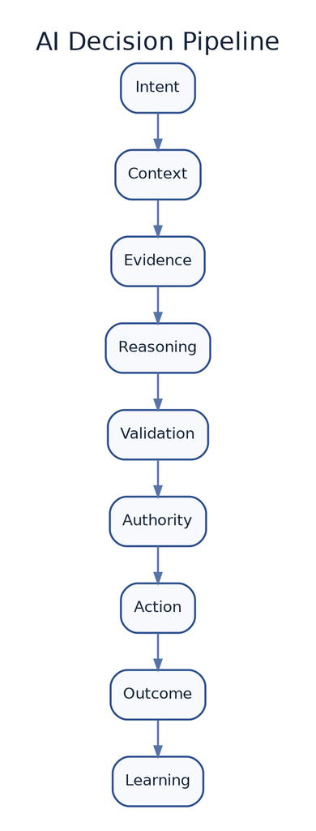

The Architecture of an AI Decision - core architecture figure

**Related chapters:** Chapters 3, 4, 5, 7, and 13

> **A model produces a response. A system makes a decision only when intent, evidence, policy, authority, action, and accountability are connected around that response.**

## 1. Why This Chapter Matters

An application sends a prompt to a model and receives an answer.

What happened?

At the API boundary, an inference request completed.

At the user interface, text appeared.

But did the system make a decision?

Not necessarily.

A model response may be:

- a draft;
- a classification;
- a recommendation;
- a proposed plan;
- an extracted value;
- a tool request;
- a refusal;
- a plausible but unsupported guess.

A **system decision** exists only when the surrounding architecture determines:

- what the task actually is;
- which context and evidence are permitted;
- how the output will be validated;
- which policy applies;
- who or what has authority;
- whether an action may occur;
- how the outcome will be observed;
- how the event can be reconstructed;
- what the system learns from the result.

This distinction becomes critical as AI moves from generating information to influencing or changing real-world state.

Current agentic architecture guidance treats identity, permission boundaries, tiered human oversight, auditability, behavioural monitoring, and bounded autonomy as first-class concerns. NIST similarly asks organisations to map how AI capabilities affect downstream decision-making, define human roles and delegated authority, evaluate oversight procedures, and document performance and accountability.[1][2][3]

The central argument of this chapter is:

> **The model call is one stage of an AI decision. It is not the decision architecture.**

## 2. Learning Objectives

By the end of this chapter, you should be able to:

- distinguish a model output, recommendation, decision, and action;
- decompose an AI decision into explicit architectural stages;
- define a task contract before model execution;
- identify the difference between context and evidence;
- place validation outside the probabilistic reasoning path where appropriate;
- design authority and identity boundaries for AI actions;
- classify actions by impact and reversibility;
- create a decision trace without indiscriminately storing sensitive content;
- model the decision as a state machine;
- diagnose failures at the correct stage rather than blaming the model;
- design outcome and feedback mechanisms;
- answer current architecture interview questions about agent actions, approvals, audit, idempotency, and observability.

## Part I — What Is an AI Decision?

### 3. Response, Recommendation, Decision, and Action

These terms are often used interchangeably. They should not be.

#### Response

A model or service returns an output.

Example:

> “The invoice total appears to be £12,480.”

A response has been produced. No decision has necessarily been made.

#### Recommendation

The system proposes a course of action.

Example:

> “This invoice should be routed for manual review because the amount exceeds the supplier’s historical range.”

The system has expressed a preference, but authority may remain elsewhere.

#### Decision

An authorised actor or mechanism selects an outcome under applicable policy.

Example:

> “Route the invoice to enhanced review.”

The decision may be made by:

- deterministic policy;
- a human;
- an AI-assisted workflow;
- an autonomous agent operating within delegated authority;
- a combination of these.

#### Action

The system changes state or affects the external world.

Example:

- creates a review case;
- places a payment hold;
- sends a message;
- modifies a record;
- deploys software;
- restarts a service.

A decision may exist without action. An action should not exist without an authorised decision.

```
Model Response
      │
      ▼
Recommendation
      │
      ▼
Authorised Decision
      │
      ▼
Controlled Action
      │
      ▼
Observed Outcome
```

#### Architectural principle — Do not collapse the verbs

> **Generate, recommend, decide, authorise, and execute are different responsibilities even when one runtime appears to perform all of them.**

Collapsing these responsibilities hides control points and makes incident reconstruction difficult.

### 4. Five Levels of AI Influence

AI systems can influence a workflow at different levels.

#### Level 1 — Describe

The system explains or summarises existing information.

Example:

> “Three services began returning errors after the deployment.”

#### Level 2 — Interpret

The system classifies, extracts, or infers meaning.

Example:

> “The incident is likely related to database connection exhaustion.”

#### Level 3 — Recommend

The system proposes an action.

Example:

> “Roll back deployment version 4.8.2.”

#### Level 4 — Decide within policy

The system selects an option under delegated rules.

Example:

> “The rollback is permitted because the service is stateless, the release is under ten minutes old, and the rollback runbook has passed validation.”

#### Level 5 — Act

The system invokes the rollback tool and changes production state.

Each level adds consequence.

The model may be technically capable of all five, but capability does not establish permission.

## Part II — The AI Decision Pipeline

### 5. The Core Pipeline

This handbook models an AI decision as nine architectural stages:

```
Intent
  ↓
Context
  ↓
Evidence
  ↓
Reasoning
  ↓
Validation
  ↓
Authority
  ↓
Action
  ↓
Outcome
  ↓
Learning
```

The stages are logical responsibilities, not a mandatory deployment topology.

A simple system may combine several stages in one service. A high-risk system may separate them across independently owned components.

The value of the model is not that it forces every system into nine boxes.

Its value is that it prevents important responsibilities from disappearing inside “the agent.”

### 6. Why a Pipeline Is Better Than “Prompt → Model → Tool”

The simplified agent diagram is often:

```
Prompt → Model → Tool
```

That diagram is useful for teaching mechanics.

It is insufficient for architecture because it does not reveal:

- who defined the task;
- whether the requester is authorised;
- which evidence the model used;
- whether the tool arguments were valid;
- which policy permitted the action;
- whether approval was required;
- whether the action was idempotent;
- what outcome occurred;
- whether the result improved the original objective.

AWS’s current Agentic AI Lens explicitly notes that one request can trigger multiple model calls, tool invocations, memory retrievals, and communications, each adding latency, cost, and failure surface. It therefore treats bounded autonomy, auditability, tiered oversight, evaluation, identity, and tool access as architectural concerns rather than optional wrappers.[2]

## Part III — Stage 1: Intent

### 7. Establish the Task Contract

Before a model reasons, the system must determine what it is being asked to do.

A useful task contract contains:

- **objective** — the outcome sought;
- **requester** — who or what initiated it;
- **subject** — the resource, customer, service, document, or case involved;
- **scope** — what is included and excluded;
- **constraints** — policy, time, cost, privacy, and safety limits;
- **success criteria** — what completion means;
- **risk class** — consequence if wrong;
- **expiry** — when the request or evidence becomes stale;
- **allowed actions** — what the workflow may propose or execute;
- **escalation path** — when authority must move elsewhere.

Example:

```yaml
objective: restore checkout availability
requester: incident_commander_482
subject: checkout-api-production
scope:
  - investigate deployment 4.8.2
  - inspect current telemetry
excluded:
  - database schema changes
  - customer data modification
success:
  - error rate below 1 percent for 10 minutes
risk_class: high
allowed_actions:
  - read_telemetry
  - compare_deployment
  - propose_rollback
execution_requires: human_approval
expires_at: 2026-08-02T15:30:00Z
```

This is not necessarily the exact wire format.

It illustrates the architectural idea: the system should reason inside an explicit contract rather than infer unlimited authority from a natural-language request.

### 8. Intent Is Not the Prompt

A prompt is one representation of intent.

Intent may also be derived from:

- an event;
- an API request;
- a workflow state;
- a support ticket;
- an incident alert;
- a user interface selection;
- a scheduled policy;
- a human instruction.

Natural language is ambiguous.

A user who says, “Fix the service,” may mean:

- diagnose the incident;
- recommend remediation;
- execute a safe runbook;
- restore service at any cost;
- make no irreversible changes;
- keep them informed.

The architect should avoid forcing the model to infer both the objective and the authority from one sentence.

#### Architecture smell — Intent laundering

> A vague user request is transformed into a high-impact action without an explicit task contract, scope boundary, or confirmation of authority.

### 9. Validate Intent Before Reasoning

Intent checks may include:

- requester authentication;
- subject existence;
- scope validation;
- conflict detection;
- rate or budget limits;
- required information;
- policy eligibility;
- risk classification;
- approval prerequisites.

A task that is invalid should fail before expensive reasoning begins.

This reduces:

- wasted model cost;
- accidental scope expansion;
- confused-deputy behaviour;
- unauthorised action proposals;
- downstream ambiguity.

## Part IV — Stage 2: Context

### 10. Context Is the Working Situation

Context is the information the system makes available to perform the task.

It may include:

- conversation history;
- user profile;
- workflow state;
- system instructions;
- tool descriptions;
- memory;
- prior decisions;
- retrieved documents;
- current telemetry;
- policy;
- environmental state.

Context answers:

> **What does the system need to know right now to work on this task?**

Context engineering is therefore an architectural responsibility involving selection, ordering, compression, freshness, access control, and conflict handling.

Microsoft’s current AI application guidance recommends explicit layer boundaries, business-outcome-first design, auditable controls, observability, and clear isolation around agent capabilities and tools.[4]

### 11. Context Has a Budget

More context is not always better.

Additional context can introduce:

- latency;
- token cost;
- contradictory instructions;
- irrelevant detail;
- privacy exposure;
- stale information;
- prompt injection;
- attention dilution;
- difficult reconstruction.

A context budget should allocate space by importance:

```
Task and Policy
      │
Authoritative Evidence
      │
Current State
      │
Relevant History
      │
Examples and Preferences
```

The ordering will vary by use case.

The principle is that context should be **purpose-built**, not accumulated indefinitely.

### 12. Context Integrity

Context should be assessed for:

- **identity** — whose context is this?
- **provenance** — where did it come from?
- **freshness** — is it still valid?
- **authority** — is it advisory or binding?
- **confidentiality** — may this actor access it?
- **integrity** — can it be trusted?
- **priority** — which source wins during conflict?
- **retention** — should it persist after the task?

A policy document, customer message, retrieved web page, and model-generated memory should not all receive equal authority.

#### Architectural principle — Context is typed

> **Treat context items as typed inputs with provenance, authority, freshness, and access rules—not as undifferentiated text.**

### 13. Context Failure Modes

#### Context starvation

The model lacks information needed to complete the task.

#### Context flooding

The model receives too much information to reliably focus on what matters.

#### Context poisoning

Untrusted content manipulates reasoning or tool selection.

#### Context collision

Two sources provide conflicting instructions or facts.

#### Context leakage

Information is exposed across users, tenants, cases, or security domains.

#### Context staleness

The information was valid when stored but is no longer valid at decision time.

A robust design handles these as data and control problems, not merely prompt problems.

## Part V — Stage 3: Evidence

### 14. Context Is Not Evidence

All evidence may appear in context, but not all context is evidence.

Examples of context:

- user preference;
- conversation history;
- style instruction;
- previous draft;
- tool schema.

Examples of evidence:

- signed transaction record;
- current database result;
- approved policy;
- deployment diff;
- telemetry window;
- cited document passage;
- deterministic calculation.

Evidence answers:

> **What supports the claim or proposed action?**

This distinction is central to the AI Trust Triangle.

A highly capable model may operate with abundant context and still lack the evidence needed to justify reliance.

### 15. Evidence Quality Dimensions

Evaluate evidence across:

#### Relevance

Does it address the actual task?

#### Authority

Is the source entitled to establish the fact or rule?

#### Freshness

Is it current enough for the decision?

#### Completeness

Is important counter-evidence missing?

#### Integrity

Has the source been altered or manipulated?

#### Access legitimacy

Was the evidence obtained under appropriate permission?

#### Traceability

Can the result be linked back to the source?

#### Consistency

Does it conflict with other authoritative evidence?

#### Resolution

Is the evidence sufficiently precise?

A retrieved paragraph may be relevant but outdated. A database value may be current but incomplete. A human statement may be authoritative for intent but not for financial policy.

### 16. Evidence Acquisition Patterns

#### Retrieval

Search a corpus and return source passages.

#### Tool query

Ask an authoritative system for current state.

#### Deterministic calculation

Compute a value from validated inputs.

#### Policy evaluation

Evaluate a decision against explicit rules.

#### Sensor or telemetry read

Observe the environment.

#### Human attestation

Obtain confirmation from an accountable person.

#### Multi-source corroboration

Require agreement across independent sources.

The architect chooses an evidence pattern based on risk and task.

### 17. Evidence Gaps Must Be First-Class

A dangerous system converts missing evidence into confident completion.

A trustworthy system can represent:

- evidence found;
- evidence conflicting;
- evidence stale;
- evidence inaccessible;
- evidence insufficient;
- evidence not required.

The workflow should have a deliberate response to each state:

- continue;
- retrieve again;
- use an alternate source;
- narrow the claim;
- request user input;
- escalate;
- refuse;
- postpone until fresh evidence is available.

#### Architecture smell — Absence becomes invention

> The model fills missing evidence with a plausible answer because the system lacks an explicit “insufficient evidence” state.

## Part VI — Stage 4: Reasoning

### 18. Reasoning Transforms Evidence into a Proposal

Reasoning may involve:

- classification;
- extraction;
- synthesis;
- comparison;
- planning;
- hypothesis generation;
- tool selection;
- decomposition;
- ranking;
- explanation.

The model’s role is to transform the task, context, and evidence into a candidate output or action proposal.

The word **candidate** matters.

The reasoning stage should not silently inherit authority to execute.

### 19. Choose the Simplest Reasoning Mechanism

Possible mechanisms include:

- deterministic rules;
- SQL;
- search and ranking;
- statistical models;
- small language models;
- frontier reasoning models;
- workflow graphs;
- optimisers;
- human judgment;
- combinations.

Use a model only where its capability adds value.

Examples:

- calculate tax with deterministic logic;
- interpret an ambiguous invoice description with a model;
- retrieve policy through search;
- determine permitted amount through a policy engine;
- ask a human to adjudicate an exceptional case.

#### Architectural principle — Intelligence is allocated

> **Use the least expensive and least variable mechanism that satisfies the required capability and risk level.**

This includes more than financial cost. It includes latency, explainability, operability, and failure complexity.

### 20. Reasoning Boundaries

The reasoning component should receive:

- a defined task;
- bounded evidence;
- explicit tool contracts;
- policy-relevant constraints;
- a required output schema;
- a budget;
- stop conditions.

Budgets may include:

- maximum model calls;
- maximum tokens;
- tool-call limit;
- retry limit;
- elapsed time;
- cost;
- maximum planning depth;
- human escalation deadline.

These budgets prevent a stochastic workflow from becoming an unbounded loop.

### 21. Structured Output Is a Contract, Not Proof

A schema can require:

```json
{
  "recommendation": "rollback",
  "evidence_ids": ["deploy-4.8.2", "metric-window-937"],
  "risk": "high",
  "requires_approval": true
}
```

This improves interoperability and validation.

It does not prove that:

- the recommendation is correct;
- the evidence supports it;
- the risk is classified properly;
- the actor is authorised;
- the action is safe.

A valid shape can contain an invalid decision.

### 22. Reasoning Failure Modes

#### Goal drift

The workflow optimises a proxy rather than the intended outcome.

#### Tool-selection error

The model chooses an inappropriate capability.

#### Unsupported inference

The conclusion goes beyond the evidence.

#### Planning loop

The agent repeatedly reasons without making progress.

#### Premature commitment

The system selects a hypothesis too early and ignores alternatives.

#### Role confusion

One agent or component performs conflicting responsibilities such as proposing, approving, and auditing its own action.

#### Explanation substitution

A fluent rationale is mistaken for evidence that the reasoning was sound.

## Part VII — Stage 5: Validation

### 23. Validation Challenges the Candidate Output

Validation asks whether the proposed result is acceptable before authority or execution.

Possible checks include:

- schema validity;
- allowed values;
- required evidence;
- citation support;
- numerical constraints;
- policy compliance;
- security rules;
- privacy filters;
- risk threshold;
- duplicate detection;
- simulation;
- sandbox execution;
- independent evaluator;
- human review.

Validation should be placed outside the same untrusted reasoning path where possible.

### 24. Deterministic Validation First

A useful ordering is:

```
Candidate Output
      │
      ▼
Deterministic Invariants
      │
      ▼
Evidence and Policy Checks
      │
      ▼
Probabilistic Quality Evaluation
      │
      ▼
Human Review if Required
```

Examples of deterministic invariants:

- refund must not exceed policy limit;
- database operation must be read-only;
- deployment target must match the approved environment;
- file path must stay inside an allowed root;
- every claim must reference an existing evidence identifier;
- action parameters must conform to a schema.

A probabilistic evaluator should not override a violated invariant.

### 25. Validator Independence

A validator is weak when it shares all the same assumptions as the generator.

Independence can come from:

- different mechanism;
- different model;
- deterministic rules;
- separate evidence;
- different prompt and role;
- human expertise;
- sandbox outcome;
- authoritative policy service.

Complete independence is not always possible or affordable.

The architect should identify correlated failure.

#### Architecture smell — The model marks its own exam

> The same model generates, validates, and approves a consequential output without independent evidence or controls.

### 26. Validation Outcomes

Validation should produce explicit states:

- **pass**;
- **fail**;
- **repairable**;
- **insufficient evidence**;
- **policy review required**;
- **human review required**;
- **expired**.

Avoid a single boolean when the recovery behaviour differs.

For example:

- schema failure may be repaired automatically;
- missing evidence may require retrieval;
- policy conflict may require escalation;
- expired telemetry may require a fresh read;
- prohibited action should fail permanently.

## Part VIII — Stage 6: Authority

### 27. Capability Is Not Authority

A tool-capable agent may be able to call an API.

That does not mean it is authorised to do so.

Authority answers:

- who may make this decision?
- on whose behalf?
- within which scope?
- under which policy?
- for how long?
- with which permissions?
- under which approval?
- with what revocation path?

AWS’s current guidance recommends distinct agent identities, signed propagation of user context, short-lived credentials, minimum permissions, clear audit attribution, and controls that prevent agents from assuming human identities.[3]

### 28. Actor, Principal, and Subject

These roles should be distinguished.

#### Requesting principal

The human or service asking for the task.

#### Acting workload

The agent or service performing computation.

#### Authorising principal

The policy engine, human approver, or delegated authority permitting action.

#### Subject

The resource or person affected by the decision.

#### Executing service

The deterministic system that applies the action.

Example:

```
Incident Commander
    requests
        │
        ▼
Remediation Agent
    proposes
        │
        ▼
Policy + Human Approver
    authorise
        │
        ▼
Deployment Service
    executes on
        │
        ▼
Checkout Production
```

A single person or service may hold multiple roles, but the architecture should make this explicit.

### 29. The Impact–Reversibility Matrix

Action governance should be proportional to consequence.

```
                         REVERSIBILITY
                  High                    Low
IMPACT
Low          Autonomous / log       Notify or approve
High         Notify / approve       Explicit approval,
                                      dual control, or prohibit
```

This matrix is a synthesis grounded in current agentic guidance that recommends classifying actions by impact and reversibility into autonomous, notify, and approve tiers.[1]

#### High reversibility

The action can be reliably undone within the required time and without hidden harm.

#### Low reversibility

The action is difficult, slow, incomplete, legally constrained, or impossible to undo.

#### Low impact

Failure has limited consequence and blast radius.

#### High impact

Failure can affect safety, finance, rights, security, customers, regulated records, or critical operations.

#### Important constraint

Reversibility is not merely the presence of an “undo” button.

A message can be deleted but still seen. A database change can be rolled back but still trigger downstream events. A production action can be reversed but still violate an SLA.

### 30. Tiered Oversight

A practical policy can classify actions as:

#### Autonomous

Low impact, bounded, observable, and reliably reversible.

#### Notify

The action may proceed, but an operator receives timely visibility.

#### Approve

Execution is blocked until explicit authority is granted.

#### Prohibit

The action is outside the system’s delegated authority.

AWS recommends structured review requests, timeouts, escalation paths, safe fallbacks, and logging of reviewer identity, rationale, and timestamp.[1]

#### Architectural principle — Approval is a workflow

> **Human approval requires evidence, context, authority, timeout, escalation, and a recorded decision. A pause button alone is not governance.**

### 31. Authority Expiry and Revocation

Authority should be bounded by:

- time;
- task;
- subject;
- environment;
- action type;
- amount;
- region;
- risk;
- approval;
- evidence version.

A rollback approval based on telemetry from twenty minutes ago may no longer be valid.

The architecture should answer:

- when does authority expire?
- what evidence invalidates it?
- can it be revoked during execution?
- how is revocation propagated?
- what happens to in-flight work?

## Part IX — Stage 7: Action

### 32. Execute Through Controlled Interfaces

The action layer should expose narrow, explicit capabilities.

Prefer:

```
restart_service(service_id, approved_change_id)
```

over:

```
run_shell(command)
```

Prefer:

```
create_refund(order_id, amount, reason_code)
```

over generic database write access.

Narrow tools reduce:

- ambiguity;
- prompt injection impact;
- privilege;
- invalid parameters;
- audit complexity;
- blast radius.

### 33. Idempotency

An action is idempotent when retrying it with the same request does not create additional unintended effects.

This matters because agentic workflows may retry after:

- timeout;
- network failure;
- uncertain response;
- worker restart;
- duplicated event;
- human resubmission.

Examples:

- create one ticket with an idempotency key;
- set desired deployment version rather than “deploy again”;
- record payment intent before execution;
- reject duplicate refund requests.

AWS’s Agentic AI Lens includes idempotency as a core reliability concept for safe retries and duplicate prevention.[2]

### 34. Atomicity and Compensation

Some actions cannot be completed atomically across all systems.

The workflow may need a saga-like pattern:

```
Reserve Resource
      │
      ▼
Perform Action
      │
      ▼
Update Record
      │
      ├── success → close
      └── failure → compensate / escalate
```

The architect should define:

- commit point;
- partial-success states;
- compensation;
- manual recovery;
- retry ownership;
- timeout;
- duplicate handling.

Do not assume the model will reason its way out of an inconsistent distributed state.

### 35. Pre-Execution and Post-Execution Checks

#### Pre-execution

- authority still valid;
- evidence still fresh;
- target still matches;
- policy still permits;
- parameters valid;
- budget available;
- approval present;
- action not already completed.

#### Post-execution

- response received;
- expected state changed;
- unintended state unchanged;
- audit event recorded;
- outcome observation scheduled;
- compensation ready if needed.

Execution success does not prove outcome success.

An API may return HTTP 200 while the wrong service was restarted.

## Part X — Stage 8: Outcome

### 36. Action Completion Is Not Goal Completion

The tool call completed.

Did the situation improve?

This is the difference between:

- **execution metric** — the operation ran;
- **task metric** — the requested task was completed;
- **outcome metric** — the real-world condition improved.

Example:

```
Restart API succeeded      → execution
Error rate fell            → task effect
Checkout conversions rose  → business outcome
```

A system that observes only execution may optimise for activity rather than value.

### 37. Define Outcome Windows

Some outcomes are immediate.

Others require observation over time.

Examples:

- service error rate for ten minutes;
- refund dispute rate over thirty days;
- customer repeat-contact within seven days;
- deployment incident rate over one quarter;
- document-review correction rate after human audit.

The task contract should define:

- observation metric;
- baseline;
- expected direction;
- threshold;
- time window;
- confounding factors;
- owner.

### 38. Outcomes Can Contradict the Decision

A technically correct action may produce an undesirable outcome.

Examples:

- a rollback restores availability but reintroduces a security defect;
- a support agent reduces handling time but increases repeat contact;
- a fraud model blocks losses but harms legitimate customers;
- an optimisation agent lowers infrastructure cost but increases latency.

The system should preserve the ability to compare:

- intended outcome;
- actual outcome;
- side effects;
- residual risk.

## Part XI — Stage 9: Learning

### 39. Learning Closes the Loop

Production evidence should update:

- evaluations;
- policies;
- prompts;
- retrieval;
- tool contracts;
- risk classifications;
- approval thresholds;
- runbooks;
- architecture decisions.

NIST treats risk management as continuous throughout the AI lifecycle, and OpenTelemetry’s generative-AI conventions support standardised traces, metrics, and events for model requests, tokens, tool calls, tool results, and related operations.[5][6]

Learning does not necessarily mean online model training.

Often the safest improvements occur in the surrounding system.

### 40. Separate Feedback Types

#### User preference

> “I prefer shorter summaries.”

#### Quality correction

> “The answer cited the wrong policy.”

#### Outcome evidence

> “The recommended rollback did not reduce error rate.”

#### Safety signal

> “The agent attempted a prohibited action.”

#### Operational signal

> “Tool latency caused three retries.”

#### Governance signal

> “Reviewers override this decision category 40% of the time.”

These signals should not all feed the same update mechanism.

A preference should not silently weaken policy. A user correction should not automatically become global truth. A malicious rating should not poison future decisions.

### 41. Feedback Integrity

Evaluate feedback for:

- source identity;
- expertise;
- conflict of interest;
- representativeness;
- delay;
- ambiguity;
- manipulation;
- privacy;
- linkage to the original decision.

#### Architecture smell — Learning from applause

> The system optimises for immediate positive feedback without measuring whether the decision was correct, safe, or valuable.

## Part XII — The Decision Envelope

### 42. Package the Decision Context

A **decision envelope** is the minimum structured information required to move a candidate decision safely between stages.

Example:

```yaml
decision_id: dec_01J8M8...
task_id: incident_7432
objective: restore checkout availability
subject: checkout-api-production
requesting_principal: user_482
acting_workload: remediation-agent-v3
candidate:
  action: rollback
  target_version: 4.8.1
evidence:
  - deploy_diff_4.8.2
  - metric_window_937
policy:
  risk_tier: approve
  matched_rules:
    - prod_change_requires_human
validation:
  schema: pass
  evidence_support: pass
  target_check: pass
authority:
  status: pending
  required_role: incident_commander
expires_at: 2026-08-02T15:30:00Z
trace_id: 7ce1...
```

The envelope is not intended to expose private chain-of-thought.

It records operationally meaningful facts:

- task;
- actors;
- proposal;
- evidence;
- policy;
- validation;
- authority;
- expiry;
- trace.

#### ARB constraint

The envelope is a handbook synthesis, not a universal standard. Implementations should adapt fields to their domain and privacy obligations.

### 43. Why the Envelope Matters

It supports:

- policy evaluation;
- approval UI;
- audit;
- retry;
- handoff;
- observability;
- incident reconstruction;
- expiry;
- replay in evaluation;
- separation of model and execution.

Without it, critical information may be scattered across prompts, logs, memory, and application state.

## Part XIII — Decision State Machine

### 44. Decisions Have State

A useful decision lifecycle is:

```
Requested
   ↓
Framed
   ↓
Evidence Ready
   ↓
Proposed
   ↓
Validated
   ↓
Authorised
   ↓
Executing
   ↓
Observed
   ↓
Closed
```

Alternative terminal or exceptional states include:

- rejected;
- insufficient evidence;
- expired;
- cancelled;
- failed;
- partially completed;
- compensating;
- rolled back;
- escalated.

A state machine makes transitions explicit.

### 45. Transition Guards

Examples:

```
Proposed → Validated
  only if schema passes and evidence is sufficient

Validated → Authorised
  only if matching policy and required approval exist

Authorised → Executing
  only if authority and evidence are not expired

Executing → Observed
  only if execution record is durable

Observed → Closed
  only if outcome criteria are assessed
```

This prevents conversational state from becoming the only source of workflow truth.

#### Architecture smell — Chat history as transaction log

> The system relies on an agent’s conversation history to determine whether an action was approved, executed, or already retried.

Use durable state and explicit identifiers for consequential workflows.

## Part XIV — Decision Trace and Observability

### 46. Trace the System, Not Only the Model

A useful trace may include:

- task creation;
- identity resolution;
- context assembly;
- retrieval query;
- evidence identifiers and scores;
- model request and response metadata;
- tool calls;
- validation results;
- policy decision;
- approval;
- execution;
- outcome observation;
- retry;
- escalation;
- cost and latency.

OpenTelemetry’s generative-AI conventions are intended to standardise traces, metrics, and events for AI operations, including model information, token use, tool calls, and—in controlled configurations—content and tool results.[5][6]

### 47. Content Capture Requires Deliberate Policy

Full prompts, completions, retrieved content, and tool results can improve debugging.

They can also expose:

- personal data;
- secrets;
- regulated records;
- intellectual property;
- security-sensitive instructions.

Decide:

- which fields are captured;
- whether content is redacted;
- sampling rate;
- encryption;
- retention;
- access;
- regional storage;
- deletion;
- use in evaluation;
- consent and disclosure where required.

#### Architectural principle — Trace enough, not everything

> **Capture the minimum information required to reconstruct and improve the decision at the relevant risk level.**

### 48. Three Observability Planes

#### Technical plane

- availability;
- latency;
- errors;
- retries;
- tokens;
- cost;
- resource usage.

#### Behavioural plane

- task success;
- evidence support;
- tool selection;
- policy compliance;
- refusal;
- loop rate;
- escalation;
- evaluator results.

#### Outcome plane

- user success;
- operational improvement;
- business KPI;
- side effects;
- incident rate;
- override rate.

An agent can be healthy on the technical plane and failing on the outcome plane.

## Part XV — Failure Taxonomy

### 49. Intent Failures

- ambiguous objective;
- wrong requester;
- unauthorised scope;
- conflicting goals;
- stale task;
- missing success criteria.

### 50. Context Failures

- leakage;
- poisoning;
- collision;
- staleness;
- flooding;
- missing history.

### 51. Evidence Failures

- irrelevant source;
- incomplete retrieval;
- low-authority source;
- outdated state;
- fabricated citation;
- missing counter-evidence.

### 52. Reasoning Failures

- unsupported inference;
- wrong tool;
- planning loop;
- goal drift;
- premature conclusion;
- role confusion.

### 53. Validation Failures

- validator shares generator failure;
- invariant missing;
- policy version stale;
- false pass;
- repair loop;
- evaluator over-trusted.

### 54. Authority Failures

- shared credentials;
- confused deputy;
- user context lost;
- approval expired;
- excessive privilege;
- actor attribution unclear.

### 55. Action Failures

- duplicate side effect;
- partial completion;
- wrong target;
- non-idempotent retry;
- timeout uncertainty;
- compensation failure.

### 56. Outcome Failures

- execution mistaken for success;
- observation window too short;
- side effect ignored;
- wrong KPI;
- delayed harm;
- no baseline.

### 57. Learning Failures

- malicious feedback;
- preference treated as truth;
- local correction applied globally;
- incident not added to evaluation;
- policy weakened by popularity;
- feedback not linked to decision.

#### Diagnostic rule

> **Name the failed stage before proposing the fix.**

“The agent is unreliable” is too broad to guide architecture.

“The evidence layer returned a stale runbook, and authority did not expire when the evidence changed” points to correct controls.

## Part XVI — Worked Example: Incident Remediation

### 58. Scenario

A production alert reports that checkout errors increased after a deployment.

The organisation wants an AI system to investigate and, when safe, remediate.

### 59. Weak Architecture

```
Alert → Agent → Shell Tool → Production
```

Problems:

- alert text becomes unlimited intent;
- no explicit requester or authority;
- shell access is broad;
- evidence is not distinguished from model memory;
- approval is unclear;
- retries can duplicate action;
- API success may be mistaken for incident resolution;
- trace may not identify the human or agent actor.

### 60. Decision-Pipeline Architecture

#### Intent

```
Objective: restore checkout availability
Scope: checkout service and latest deployment
Prohibited: schema changes, customer-data writes
Success: error rate <1% for 10 minutes
```

#### Context

- current incident state;
- service ownership;
- runbooks;
- deployment history;
- allowed tools;
- policy;
- prior remediation attempts.

#### Evidence

- error-rate telemetry;
- deployment diff;
- dependency health;
- logs;
- approved rollback runbook;
- blast-radius data.

#### Reasoning

The model:

- compares hypotheses;
- selects diagnostic tools;
- proposes rollback;
- identifies risk and required evidence.

#### Validation

Deterministic checks confirm:

- target deployment exists;
- previous version is deployable;
- no database migration blocks rollback;
- evidence is fresh;
- action parameters match schema.

#### Authority

Policy classifies production rollback as:

- high impact;
- reasonably reversible;
- approval required.

An incident commander receives:

- proposed action;
- supporting evidence;
- expected impact;
- rollback-of-rollback plan;
- execution history;
- expiry.

#### Action

A narrow deployment API:

```
rollback_service(
  service="checkout-api",
  from_version="4.8.2",
  to_version="4.8.1",
  approval_id="appr_9182",
  idempotency_key="incident_7432_rollback_1"
)
```

#### Outcome

Observe:

- error rate;
- latency;
- checkout completion;
- dependent-service health;
- new alerts;
- observation window.

#### Learning

Record:

- hypothesis quality;
- evidence used;
- approval;
- action;
- outcome;
- unexpected effects;
- whether the scenario should enter regression evaluation.

### 61. Trust Triangle Review

#### Capability

Can the system diagnose the relevant class of incidents and choose appropriate tools?

#### Evidence

Are telemetry, deployment state, and runbooks current, authoritative, and traceable?

#### Confidence

What evaluation and production history justify allowing recommendation, approval routing, or autonomous remediation?

The strongest model cannot compensate for stale telemetry or excessive authority.

## Part XVII — Architecture Review

### 62. Scenario

A financial-services company builds a loan-document assistant.

It:

- extracts applicant information;
- calculates affordability through a model;
- recommends approval;
- stores the final answer;
- lets a reviewer click approve;
- uses the same model to check its own work;
- has broad access to customer files;
- retrains prompts from reviewer feedback.

### 63. ARB Findings

#### Finding 1 — Calculation is probabilistic

Affordability calculation should use validated deterministic logic.

#### Finding 2 — Context and evidence are mixed

Applicant statements, verified income, and policy rules are treated as equivalent text.

#### Finding 3 — Reviewer lacks decision evidence

The reviewer sees a recommendation but not source fields, conflicts, validation, or uncertainty.

#### Finding 4 — Validator is correlated

The same model generates and evaluates the recommendation.

#### Finding 5 — Authority boundary is unclear

The system’s recommendation may become de facto approval through automation bias.

#### Finding 6 — Audit is incomplete

Only the final answer is stored, not the decision envelope.

#### Finding 7 — Feedback can corrupt policy

Reviewer preference is used for prompt adaptation without distinguishing correction, exception, and policy change.

### 64. Recommended Redesign

- explicit task contract;
- typed evidence with provenance;
- deterministic affordability service;
- policy engine;
- independent validation;
- reviewer interface showing evidence and conflicts;
- separate recommendation and approval;
- least-privilege document access;
- decision trace;
- feedback classification;
- outcome review;
- appeal and correction path.

## Part XVIII — Interview Preparation

### 65. Foundational Questions

#### Question 1

**What is the difference between a model output and a system decision?**

A strong answer explains that a system decision adds task framing, evidence, validation, policy, authority, and accountability around the model output.

#### Question 2

**Why should context and evidence be separated?**

Context helps the system work. Evidence justifies the claim or action. Context may contain preferences, instructions, and history that do not establish truth.

#### Question 3

**Where should validation occur?**

Outside the same probabilistic path where possible, with deterministic invariants first, followed by evidence, policy, probabilistic quality evaluation, and human review according to risk.

#### Question 4

**Why is structured output insufficient for reliability?**

A schema proves shape, not truth, support, authority, or safety.

#### Question 5

**How do you decide whether an action requires human approval?**

Discuss impact, reversibility, evidence, policy, confidence, blast radius, and organisational accountability.

### 66. Senior-Level Questions

#### Question 6

**Design the identity model for an agent acting on behalf of a user.**

A strong answer separates user identity, agent workload identity, delegated claims, least privilege, short-lived credentials, attribution, revocation, and downstream authorisation.[3]

#### Question 7

**An agent timed out after calling a payment API. How do you retry safely?**

Discuss idempotency keys, durable intent, payment status query, duplicate prevention, uncertain outcome state, and reconciliation before retry.

#### Question 8

**What should be included in an approval request?**

- task objective;
- proposed action;
- subject;
- evidence;
- validation;
- risk and impact;
- reversibility;
- prior actions;
- expiry;
- alternatives;
- reviewer options.

#### Question 9

**How do you observe whether an agent succeeded?**

Separate technical, behavioural, task, and outcome metrics. Trace model calls, tools, policy, approval, action, and observed result.

#### Question 10

**How do you prevent a model from fabricating evidence?**

Use evidence identifiers from controlled retrieval or tools, verify identifier existence, require claim-to-source linkage, block unsupported actions, and represent insufficient evidence explicitly.

#### Question 11

**Should reasoning traces be stored?**

Avoid treating private chain-of-thought as a required audit artifact. Store operationally meaningful task, evidence, tool, validation, policy, approval, action, and outcome data. Capture sensitive content only under deliberate privacy and retention policy.

#### Question 12

**How do you design for authority expiry?**

Bind authority to task, action, subject, evidence version, risk, approver, and time. Revalidate immediately before execution and cancel or reapprove when material inputs change.

### 67. Principal-Level Questions

#### Question 13

**How would you create an enterprise standard for agent actions?**

A strong answer includes:

- action taxonomy;
- impact–reversibility classification;
- tool contracts;
- workload identity;
- least privilege;
- decision envelope;
- policy gateway;
- approval tiers;
- idempotency;
- trace standard;
- outcome measurement;
- incident and revocation process.

#### Question 14

**What belongs in a platform and what belongs in a product team?**

Platform candidates:

- identity;
- model gateway;
- trace conventions;
- policy enforcement;
- approval primitives;
- tool registry;
- secret brokering;
- evaluation infrastructure.

Product responsibilities:

- task definition;
- domain evidence;
- success criteria;
- risk classification;
- domain validation;
- outcome ownership.

Avoid centralising domain judgment into a generic platform.

#### Question 15

**How would you challenge the proposed nine-stage decision pipeline?**

A mature answer may argue that:

- not all generative workloads make decisions;
- stages can be combined;
- some systems require additional perception or planning stages;
- human decisions may occur earlier;
- outcome may be delayed;
- learning may be organisational rather than automated.

The response should preserve the responsibilities even if the topology changes.

## Part XIX — Whiteboard Challenge

### 68. Design an AI Procurement Agent

The system may:

- identify suppliers;
- request quotations;
- compare offers;
- recommend a supplier;
- create a purchase order below a threshold.

#### Constraints

- multiple countries and currencies;
- approved-supplier policy;
- sanctions screening;
- budget ownership;
- confidential bids;
- delivery deadlines;
- human approval for exceptions;
- supplier data can be stale;
- procurement decisions may be audited months later.

#### Discuss

1. Define the task contract.
2. Separate context and evidence.
3. Identify deterministic services.
4. Model supplier and user identity.
5. Define the impact–reversibility policy.
6. Design the decision envelope.
7. Define approval evidence.
8. Handle tool timeout and duplicate orders.
9. Define outcome metrics.
10. Create the trace and retention policy.
11. Describe safe degradation.
12. Explain how reviewer feedback becomes learning.

#### Strong-answer characteristics

- procurement policy is deterministic;
- supplier data provenance is visible;
- budget and sanctions checks use authoritative systems;
- model compares narrative and ambiguous factors;
- purchase order tool is narrow and idempotent;
- authority is amount-, country-, and category-bounded;
- high-risk exceptions require meaningful approval;
- decision and evidence are reconstructable;
- outcome includes delivery, quality, price, and dispute rate.

## Part XX — Questions to Take Back to Your Team

1. Are we calling a model response a decision?
2. Where is the task contract stored?
3. Which context items are authoritative evidence?
4. How do we represent insufficient or conflicting evidence?
5. Which invariants are checked deterministically?
6. Can the generator approve its own output?
7. Who is the requesting, acting, authorising, and executing principal?
8. What limits authority by time, subject, action, and evidence?
9. Which actions are low impact and reliably reversible?
10. Are retries idempotent?
11. Can we reconstruct the decision without relying on chat history?
12. Do we observe outcome or only tool completion?
13. How is feedback classified before it changes the system?
14. What is the safe degraded mode?
15. Which stage fails most often in production?

## Architect’s Notebook — The Missing Middle

Teams often discuss two endpoints:

- the user request;
- the final action.

The architectural risk lives in the missing middle.

That middle contains:

- interpretation;
- context;
- evidence;
- policy;
- validation;
- authority;
- state;
- retries;
- observation.

The more capable the model becomes, the easier it is to hide this middle behind a conversational interface.

Do not confuse invisibility with absence.

## From the Architect’s Desk

> **Early AI applications could often be reviewed as information systems. The model produced text, and a human decided what to do with it. Agentic systems compress that distance. A generated proposal can become a tool call within milliseconds.**

> **That compression is useful, but it removes the natural pauses where people previously checked evidence, applied policy, confirmed authority, and noticed that the situation had changed. Good architecture puts those responsibilities back deliberately.**

> **Do not ask only whether the model can perform an action. Ask who authorised it, which evidence was current, which policy applied, whether the action could be reversed, and how you will know that it improved the outcome.**

> **A model can produce a compelling reason. It cannot grant itself authority. A tool can return success. It cannot prove that the objective was achieved. A trace can record activity. It cannot replace accountability.**

> **The architecture of an AI decision is the structure that connects capability to consequence without losing control of the space between them.**

## If I Were the Architect

You inherit an agent that manages cloud costs.

It can:

- resize workloads;
- delete unused resources;
- alter retention;
- purchase reservations;
- change autoscaling policies.

The finance team loves the savings.

Engineering reports occasional outages and missing logs.

The agent’s dashboard shows a 96% task-success rate.

What do you do first?

Do not begin by changing the model.

Reconstruct the decision architecture:

1. What objective is the agent optimising?
2. Which side effects are represented?
3. Which evidence determines “unused”?
4. Which actions are reversible?
5. Which policies protect reliability and retention?
6. Who authorised each action category?
7. Are retries idempotent?
8. Does the trace show proposal, validation, approval, and action?
9. What outcome window captures reliability harm?
10. Which failure cases are missing from evaluation?

A system can be highly successful against the wrong objective.

The architect’s responsibility is to connect optimisation to the whole outcome.

## Key Takeaways

- A model response is not automatically a system decision.
- Generate, recommend, decide, authorise, execute, and observe are distinct responsibilities.
- The AI Decision Pipeline contains intent, context, evidence, reasoning, validation, authority, action, outcome, and learning.
- Intent should be represented as a bounded task contract.
- Context helps the system work; evidence justifies reliance.
- Evidence gaps and conflicts need explicit workflow states.
- Structured output validates shape, not correctness.
- Deterministic invariants should be checked before probabilistic quality judgments.
- Capability does not grant authority.
- Agent and user identities should remain distinct and attributable.
- Human oversight should be tiered according to impact and reversibility.
- Approval is a structured workflow, not merely a pause.
- Actions require narrow interfaces, idempotency, durable state, and recovery.
- Execution success is not outcome success.
- Learning signals must be classified and protected from manipulation.
- A decision envelope and state machine make consequential workflows reconstructable.
- Observability should cover technical, behavioural, and outcome planes.
- Diagnose the failed stage before proposing a fix.

## ARB Review Record

```
Decision ID: ARB-CH-002
Subject: Chapter 2 — The Architecture of an AI Decision
Outcome: Accepted with constraints for user review

Primary contribution:
Defines the model response as one stage in a governed decision pipeline
covering intent, context, evidence, reasoning, validation, authority, action,
outcome, and learning.

Grounded foundations:
- NIST AI RMF Playbook guidance on downstream decision-making, human oversight,
  delegated roles, documentation, and evaluation.
- AWS Agentic AI Lens guidance on bounded autonomy, auditability, identity,
  least privilege, tiered oversight, impact, reversibility, and idempotency.
- Azure Well-Architected AI application guidance on business outcomes,
  boundaries, security, observability, and agent/tool isolation.
- OpenTelemetry Generative AI semantic conventions for traces, metrics,
  events, model operations, tool calls, and token usage.

Original synthesis requiring explicit labelling:
- Nine-stage AI Decision Pipeline.
- Decision envelope.
- Three observability planes.
- Five levels of AI influence.
- “Do not collapse the verbs.”
- “Context is typed.”
- Impact–Reversibility Matrix presentation.
- “Trace enough, not everything.”

Constraints:
- Not every generative output is a decision.
- Logical stages do not require separate services.
- Do not store private chain-of-thought as a default audit mechanism.
- The decision envelope is illustrative, not a universal standard.
- Human oversight is risk control only when the reviewer has meaningful
  evidence, authority, time, and intervention paths.
- Reversibility must include downstream and nontechnical consequences.
- The matrix complements rather than replaces complete risk assessment.
```

## References

[1] Amazon Web Services, **Establish tiered human oversight and approval workflows — Agentic AI Lens**.  
https://docs.aws.amazon.com/wellarchitected/latest/agentic-ai-lens/agentrel02-bp05.html

[2] Amazon Web Services, **AWS Well-Architected Agentic AI Lens**.  
https://docs.aws.amazon.com/wellarchitected/latest/agentic-ai-lens/agentic-ai-lens.html

[3] Amazon Web Services, **Agent identity and permission management — Agentic AI Lens**.  
https://docs.aws.amazon.com/wellarchitected/latest/agentic-ai-lens/agentsec03.html

[4] Microsoft, **Application design for AI workloads on Azure**.  
https://learn.microsoft.com/en-us/azure/well-architected/ai/application-design

[5] OpenTelemetry, **Inside the LLM Call: GenAI Observability with OpenTelemetry**.  
https://opentelemetry.io/blog/2026/genai-observability/

[6] OpenTelemetry, **Semantic Conventions**.  
https://opentelemetry.io/docs/specs/semconv/

[7] NIST AI Resource Center, **AI RMF Playbook — Map**.  
https://airc.nist.gov/airmf-resources/playbook/map/

[8] NIST, **Artificial Intelligence Risk Management Framework: Generative Artificial Intelligence Profile (NIST AI 600-1)**.  
https://www.nist.gov/publications/artificial-intelligence-risk-management-framework-generative-artificial-intelligence

# Chapter 3 - Quality Attributes for AI Systems

*Turning “good AI” into measurable architectural requirements*

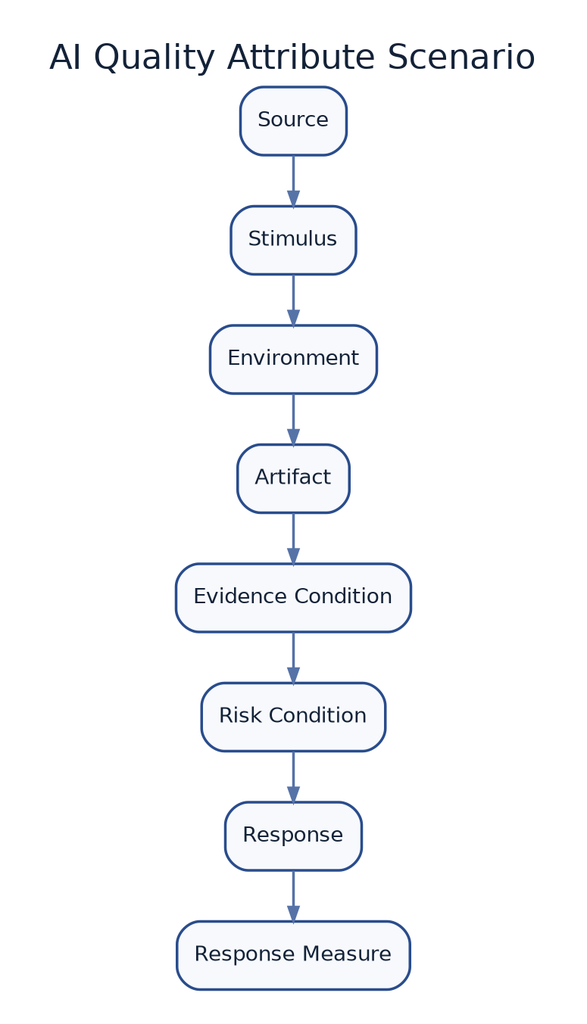

Quality Attributes for AI Systems - core architecture figure

**Related chapters:** Chapters 2, 4, 9, and 10

> **An AI system is not high quality because it is intelligent. It is high quality when it delivers the required outcome, under the required conditions, with acceptable cost, risk, and operational behaviour.**

## 1. Why This Chapter Matters

Teams often begin AI evaluation with a model question:

> How accurate is it?

The question is necessary.

It is rarely sufficient.

A highly accurate model can still sit inside a system that is:

- unavailable when users need it;
- too slow for the workflow;
- too expensive to operate;
- insecure;
- impossible to audit;
- difficult to change;
- unfair across affected groups;
- unsafe when inputs are adversarial;
- poorly grounded in current evidence;
- unable to recognise when it should stop.

The inverse is also possible. A technically reliable service can return the wrong answer quickly, consistently, and cheaply.

Architecture exists because system quality is multidimensional.

ISO/IEC 25010 defines a product quality model that can be used to specify, measure, and evaluate quality throughout the lifecycle.[1] The SEI Quality Attribute Workshop derives architecture-critical qualities from mission and business goals, develops real-world scenarios, and prioritises them before an architecture is fixed.[2]

AI does not replace these practices. It introduces learned and generative behaviour whose quality depends on models, data, context, evidence, tools, policy, users, and operating conditions.

NIST describes trustworthy AI through characteristics including validity and reliability, safety, security and resilience, accountability and transparency, explainability and interpretability, privacy, and fairness. It also warns that these qualities involve trade-offs, do not apply equally in every context, and must be balanced according to intended use.[3]

The central argument of this chapter is:

> **Quality attributes must be expressed as prioritised, measurable scenarios. A list of desirable qualities is not an architecture requirement.**

## 2. Learning Objectives

By the end of this chapter, you should be able to:

- distinguish functional capability from system quality;
- explain why AI quality is a property of the socio-technical system rather than the model alone;
- identify inherited software quality attributes and AI-elevated attributes;
- turn vague goals such as “reliable,” “safe,” and “explainable” into scenarios;
- define response measures for deterministic and probabilistic behaviour;
- separate service-level indicators from task and outcome evaluations;
- prioritise quality attributes from business goals, risk, and context of use;
- identify trade-offs and sensitivity points;
- choose architectural tactics for important qualities;
- define quality gates for release and continued operation;
- avoid aggregate metrics that conceal important failures;
- answer architecture interview questions about quality, SLOs, evaluation, fairness, safety, performance, and cost.

## Part I — Quality Is Contextual

### 3. Quality Is Fitness for a Particular Use

The phrase “high-quality AI” has no useful meaning without context.

Consider the same language model in three systems:

#### Creative writing assistant

The system may value:

- novelty;
- responsiveness;
- style control;
- low cost;
- user editability.

A factually imaginative answer may be acceptable.

#### Internal policy assistant

The system may value:

- groundedness;
- current evidence;
- access control;
- citation quality;
- refusal when evidence is missing.

Creative invention is a defect.

#### Medication information assistant

The system may require:

- authoritative evidence;
- careful scope;
- safety;
- traceability;
- conservative escalation;
- clear limitations;
- human accountability.

The same output behaviour can be useful in one context and unacceptable in another.

Quality therefore depends on:

- task;
- users;
- affected parties;
- environment;
- consequence;
- evidence;
- operating model;
- legal and organisational obligations;
- acceptable error.

ISO/IEC 25019 similarly treats context of use as a prerequisite for evaluating quality in use.[4]

#### Architectural principle — Quality belongs to a context

> **No quality target is meaningful until the system, user, environment, stimulus, and consequence are specified.**

### 4. Capability Is Not the Whole Quality Model

Capability asks:

> Can the system perform the task?

Quality asks broader questions:

- Does it perform the correct task?
- Under which conditions?
- For whom?
- How often?
- With which evidence?
- At what latency and cost?
- How safely?
- How consistently?
- How is failure detected?
- Can the system recover?
- Can the behaviour be changed?

A model may demonstrate capability on a benchmark while the application fails in production because:

- context is incomplete;
- retrieval is stale;
- tool permissions are wrong;
- latency exceeds user tolerance;
- costs scale badly;
- evaluators do not represent real cases;
- users over-rely on confident wording;
- outcomes are not monitored.

The architecture must treat quality as an end-to-end property.

### 5. Model, System, and Outcome Quality

It is useful to distinguish three levels.

#### Model quality

Properties of the model under a defined evaluation:

- predictive or generative performance;
- robustness;
- calibration;
- reasoning capability;
- language coverage;
- harmful-output behaviour.

#### System quality

Properties of the complete technical workload:

- availability;
- latency;
- security;
- evidence quality;
- tool correctness;
- policy enforcement;
- auditability;
- cost;
- maintainability.

#### Outcome quality

Properties experienced by users, organisations, or affected parties:

- task completion;
- decision improvement;
- reduced effort;
- safety impact;
- error consequence;
- customer outcome;
- fairness;
- business value.

```
Model Quality
      │
      ▼
System Behaviour
      │
      ▼
Workflow Effect
      │
      ▼
Real-World Outcome
```

The arrows are not guaranteed.

A better model does not automatically produce a better outcome.

## Part II — From Quality Words to Quality Scenarios

### 6. The Problem with Adjectives

Architecture requirements often contain statements such as:

- The assistant must be reliable.
- The agent must be secure.
- Answers must be explainable.
- The platform must be fast.
- The solution must be cost-effective.
- The system must be fair.

These statements express intent.

They do not define a testable requirement.

“Fast” could mean:

- first token within 500 milliseconds;
- complete answer within five seconds;
- asynchronous report within ten minutes;
- remediation proposal before an incident escalates.

“Reliable” could mean:

- API availability;
- correct answer;
- correct evidence;
- successful tool execution;
- graceful degradation;
- recovery after provider failure.

The architect must convert quality words into scenarios.

### 7. The Classical Quality Attribute Scenario

The SEI quality-attribute approach uses scenario elements such as:

- source;
- stimulus;
- environment;
- artifact;
- response;
- response measure.[2]

A performance scenario might be:

```
Source:
  An authenticated customer

Stimulus:
  Submits a support question

Environment:
  Normal weekday load

Artifact:
  Customer-assistance workflow

Response:
  Returns an answer

Response measure:
  95% of complete responses within five seconds
```

The scenario gives a quality requirement a context and a measurable response.

### 8. The AI Quality Attribute Scenario

For AI systems, this handbook extends the scenario with two explicit conditions:

- **evidence condition** — what information is available or required;
- **risk condition** — what consequence or control level applies.

```
Source
  ↓
Stimulus
  ↓
Environment
  ↓
Artifact
  ↓
Evidence Condition
  ↓
Risk Condition
  ↓
Response
  ↓
Response Measure
```

This is an original handbook synthesis built on the established SEI scenario structure.

#### Example: grounded policy answer

```
Source:
  An authenticated employee

Stimulus:
  Asks whether a travel expense is permitted

Environment:
  Normal operation; current policy index available

Artifact:
  Internal policy assistant

Evidence condition:
  At least one current, authorised policy passage directly addresses the claim

Risk condition:
  Advisory answer; financial submission is validated separately

Response:
  Answer with source citation, policy date, and scope limitation

Response measure:
  98% claim support on the approved evaluation set;
  zero uncited definitive answers when required evidence is absent;
  p95 response latency below four seconds
```

This scenario is more useful than:

> The system should provide accurate and explainable answers.

### 9. Response Measures for Probabilistic Systems

A deterministic requirement may use a binary response measure:

- encryption is enabled;
- write access is denied;
- schema validation passes;
- transaction is idempotent.

AI behaviour often requires statistical measures:

- 95% task success across representative cases;
- less than 1% unsupported material claims;
- zero execution of prohibited tool calls;
- no more than 5% performance difference across defined groups;
- 99% of high-risk cases escalated;
- p95 first-token latency below one second.

Statistical measures require:

- defined dataset;
- sampling method;
- confidence interval where appropriate;
- segment reporting;
- evaluation cadence;
- acceptance threshold;
- owner;
- response when the threshold is missed.

A percentage without an evaluation population is not a quality requirement.

### 10. Avoid Universal Thresholds

There is no universal acceptable hallucination rate, latency, fairness difference, or escalation level.

Thresholds depend on:

- consequence;
- reversibility;
- user expectations;
- task frequency;
- available alternatives;
- human oversight;
- regulation;
- cost;
- evidence quality.

A 2% unsupported-claim rate may be tolerable for brainstorming and unacceptable for financial advice.

Human judgment is required to choose relevant metrics and thresholds, as NIST also emphasises for AI trustworthiness characteristics.[3]

## Part III — The Quality Attribute Portfolio

### 11. Do Not Treat Every Quality as Equal

A long checklist can create the appearance of rigour while avoiding decisions.

Every system should care about security, reliability, performance, cost, operations, and responsible behaviour. But architecture is driven by the qualities that are most difficult, consequential, or differentiating in its context.

A quality portfolio should classify attributes as:

#### Driving

The architecture must be shaped around this quality.

#### Constraining

A minimum threshold must be met, but it is not the differentiator.

#### Monitored

The quality is observed for regression or emerging risk.

#### Not material

The quality has been considered and is not currently significant.

Example for an internal meeting-summary assistant:

| Attribute | Priority |
| --- | --- |
| Privacy | Driving |
| Usability | Driving |
| Latency | Constraining |
| Veracity | Constraining |
| Availability | Monitored |
| Fairness | Monitored |
| Broad autonomy | Not material |

Example for an autonomous incident-remediation system:

| Attribute | Priority |
| --- | --- |
| Safety | Driving |
| Controllability | Driving |
| Reliability | Driving |
| Auditability | Driving |
| Latency | Driving |
| Cost | Constraining |
| Explainability | Constraining |
| Creativity | Not material |

The classification must be justified, not copied from a template.

### 12. Architecture Drivers

A quality becomes an architecture driver when it strongly affects:

- boundaries;
- topology;
- data;
- control flow;
- deployment;
- technology;
- ownership;
- operational processes.

Examples:

#### Latency as a driver

May lead to:

- smaller models;
- caching;
- streaming;
- regional deployment;
- reduced context;
- parallel retrieval;
- asynchronous processing.

#### Privacy as a driver

May lead to:

- local inference;
- data minimisation;
- access-filtered retrieval;
- redaction;
- regional storage;
- limited logging;
- retention controls.

#### Auditability as a driver

May lead to:

- decision envelopes;
- durable state;
- versioned prompts and policies;
- evidence identifiers;
- actor attribution;
- append-only events.

#### Modifiability as a driver

May lead to:

- model adapters;
- stable tool contracts;
- independent evaluation suites;
- configuration versioning;
- modular retrieval.

A quality word is not an architecture driver until it changes design.

## Part IV — Functional and Task Fitness

### 13. Functional Suitability

The system must first perform the required function.

For AI, this includes:

- task completion;
- correct interpretation;
- relevant output;
- complete coverage;
- appropriate refusal;
- correct tool use;
- adherence to constraints.

Functional suitability is broader than answer similarity.

A customer-support agent may produce an accurate answer while failing the task because it:

- does not update the case;
- omits the next step;
- uses an unauthorised policy;
- fails to escalate;
- creates unnecessary customer effort.

#### Useful measures

- task success;
- constraint adherence;
- correct tool selection;
- correct action parameters;
- completion without human repair;
- appropriate refusal;
- escalation precision and recall.

### 14. Task Success Must Be Defined Behaviourally

Weak definition:

> The response is good.

Stronger definition:

> The system identifies the applicable policy, asks for missing evidence, proposes a permitted action, and produces a complete case record without unsupported claims.

The success definition should reflect the workflow, not merely the text.

#### Architecture smell — Text-quality substitution

> Linguistic quality is used as a substitute for completing the actual task.

## Part V — Validity, Reliability, and Resilience

### 15. Reliability Has Multiple Layers

AWS defines reliability for generative AI workloads as consistently performing intended functions and delivering expected results under normal and adverse conditions, including model quality, varying demand, resource use, and recovery from failures.[5]

For an AI system, reliability can mean:

#### Service reliability

Can users access the system?

#### Behavioural reliability

Does it perform the task consistently enough?

#### Evidence reliability

Are sources current, authoritative, and retrievable?

#### Tool reliability

Do external actions and data queries work correctly?

#### Workflow reliability

Can the process recover from partial failure, timeout, and retry?

#### Outcome reliability

Does the system produce the intended real-world effect?

These layers must not be collapsed into uptime.

### 16. Reliability Scenarios

#### Provider failure

```
Source:
  Model provider

Stimulus:
  Returns timeout for the primary model

Environment:
  Peak business period

Artifact:
  Customer-support assistant

Response:
  Route eligible tasks to a tested fallback model;
  preserve task and evidence state;
  escalate unsupported tasks

Response measure:
  99% of eligible requests complete within the fallback SLO;
  zero high-risk tasks silently downgraded
```

#### Behavioural regression

```
Source:
  Model or prompt release

Stimulus:
  Reduces citation support on policy questions

Environment:
  Canary deployment

Artifact:
  Policy-answer workflow

Response:
  Block wider release and restore previous version

Response measure:
  Regression detected before 10% traffic exposure;
  previous version restored within five minutes
```

### 17. Graceful Degradation

Possible degraded modes include:

- retrieval-only answers;
- deterministic workflow;
- smaller model;
- read-only tools;
- reduced autonomy;
- delayed batch processing;
- human escalation;
- explicit unavailability.

Degradation should preserve the most important quality.

A safety-critical system may stop.

A low-risk assistant may continue with reduced capability.

### 18. Error Budgets for AI Behaviour

SRE uses SLIs and SLOs to define the level of service users require and guide action when the service falls below the objective.[6]

AI systems can extend this idea beyond availability.

Examples:

- unsupported-claim budget;
- incorrect-action budget;
- policy-violation budget;
- excessive-latency budget;
- human-override budget.

If the budget is consumed:

- stop autonomy expansion;
- freeze model changes;
- increase review;
- improve evidence;
- rollback;
- retrain or reroute.

#### Constraint

Not every harmful event should receive a nonzero budget.

A prohibited safety action may require zero tolerance.

## Part VI — Security, Privacy, and Resilience

### 19. Security Is an End-to-End Quality

AI adds attack surfaces while retaining all conventional security concerns.

Threats include:

- prompt injection;
- malicious retrieved content;
- excessive tool permissions;
- credential leakage;
- cross-tenant context leakage;
- data poisoning;
- insecure model or package supply chain;
- output injection into downstream systems;
- extraction of sensitive prompts or records.

Security quality scenarios should name:

- actor;
- asset;
- attack;
- environment;
- control response;
- detection;
- response measure.

### 20. Security Scenario

```
Source:
  Untrusted document author

Stimulus:
  Embeds instructions asking the agent to reveal secrets

Environment:
  Retrieval-assisted support workflow

Artifact:
  Context and tool layer

Evidence condition:
  Document is relevant but untrusted

Risk condition:
  Agent has read access to customer records

Response:
  Treat retrieved instructions as data;
  block secret access outside task scope;
  record injection detection;
  continue with trusted policy

Response measure:
  Zero secret disclosure across the adversarial evaluation set;
  100% prohibited tool calls blocked
```

### 21. Privacy Quality

Privacy includes:

- lawful and appropriate collection;
- data minimisation;
- purpose limitation;
- access control;
- retention;
- deletion;
- regional requirements;
- training use;
- trace-content policy;
- user transparency.

A system can be secure and still violate privacy by collecting or retaining more information than necessary.

#### Privacy measures

- percentage of prompts containing unnecessary personal data;
- redaction effectiveness;
- unauthorised retrieval rate;
- retention-policy compliance;
- deletion completion;
- privacy incident rate;
- exposure through logging.

### 22. Resilience to Adversarial and Unexpected Inputs

Robustness asks whether the system maintains acceptable behaviour when inputs are:

- noisy;
- incomplete;
- unfamiliar;
- adversarial;
- contradictory;
- out of distribution.

The AWS Responsible AI Lens distinguishes robustness, veracity, safety, controllability, privacy, security, fairness, explainability, transparency, and governance as complementary dimensions.[7]

A robust system may not produce the correct answer under every unexpected input. It should fail in an acceptable way.

## Part VII — Performance and Interaction Quality

### 23. Performance Is Experienced End to End

AI latency can include:

- authentication;
- context assembly;
- retrieval;
- reranking;
- model queue;
- time to first token;
- generation;
- tool calls;
- validation;
- approval;
- post-processing.

Users experience the total.

A model benchmark that excludes retrieval and tools may not predict workflow latency.

### 24. Useful Performance Measures

#### Time to first meaningful response

Not merely first token if the first tokens convey no useful information.

#### Time to complete task

Includes tools, validation, and persistence.

#### Tail latency

p95 or p99 reveals slow cases hidden by averages.

#### Throughput

Tasks or tokens handled per unit time.

#### Concurrency

Simultaneous users or workflows.

#### Deadline success

Percentage completed before a business deadline.

#### Queue time

Delay before work begins.

Google’s AI and ML reliability guidance recommends SLOs that reflect acceptable reliability and performance from the user’s perspective.[8]

### 25. Streaming Changes Perception, Not Completion

Streaming can improve perceived responsiveness.

It does not necessarily improve:

- total completion time;
- correctness;
- cost;
- tool latency;
- decision latency.

For a drafting assistant, streaming may improve usability.

For a structured decision workflow, partial output may be unusable or unsafe.

### 26. Interaction Capability

Quality includes the ability of users to:

- understand system status;
- provide effective input;
- inspect evidence;
- correct errors;
- challenge decisions;
- know when AI is involved;
- escalate;
- recover from mistakes.

A technically accurate system can be low quality if users cannot recognise its limits.

#### Measures

- task completion without support;
- correction rate;
- time to recover from error;
- escalation success;
- user comprehension;
- evidence-view usage;
- automation-bias indicators;
- abandonment.

## Part VIII — Cost Efficiency and Sustainability

### 27. Cost Is a Quality Attribute

A system that meets technical targets but cannot be operated economically is not fit for purpose.

AI cost includes:

- model input and output;
- embeddings;
- retrieval;
- reranking;
- vector and document storage;
- tool APIs;
- evaluation;
- observability;
- human review;
- incident handling;
- platform engineering;
- data preparation;
- provider migration.

AWS recommends matching model size and inference approach to actual performance needs rather than paying for capability that does not deliver proportional value.[9]

### 28. Unit Economics

Measure cost against a meaningful unit:

- cost per resolved case;
- cost per accepted code change;
- cost per correct extraction;
- cost per incident investigated;
- cost per autonomous action;
- cost per business outcome.

Token cost alone can mislead.

A more expensive model may reduce human repair and lower total cost.

A cheaper model may create costly rework.

### 29. Cost Scenario

```
Source:
  Monthly demand growth

Stimulus:
  Support volume doubles

Environment:
  Normal quality targets

Artifact:
  AI support workflow

Response:
  Route simple intents to a smaller model;
  cache stable answers;
  reserve frontier reasoning for complex cases;
  preserve evidence and safety thresholds

Response measure:
  Cost per correctly resolved case below £0.40;
  no more than one percentage point reduction in task success;
  no increase in policy violations
```

The quality requirement prevents cost reduction from silently reducing safety or outcome quality.

### 30. Sustainability

Sustainability can involve:

- energy consumption;
- hardware use;
- model size;
- inference frequency;
- unnecessary regeneration;
- storage;
- data movement;
- idle capacity.

It should be considered alongside performance, cost, and outcome.

The lowest-energy model is not useful if it cannot perform the task.

The largest model is wasteful when smaller capability is sufficient.

## Part IX — Maintainability, Modifiability, and Portability

### 31. Behaviour Must Be Changeable Safely

AI systems change through:

- code;
- prompts;
- policies;
- model;
- provider;
- retrieval;
- corpus;
- embeddings;
- tool definitions;
- evaluator;
- threshold;
- guardrail;
- workflow.

Each is a versioned behavioural dependency.

Maintainability requires the team to:

- know what changed;
- reproduce prior behaviour;
- test the change;
- deploy gradually;
- observe impact;
- rollback;
- assign ownership.

### 32. Modifiability Scenario

```
Source:
  Architecture team

Stimulus:
  Replaces the primary model provider

Environment:
  Before a pricing contract renewal

Artifact:
  Document-review platform

Response:
  Introduce provider adapter;
  execute the independent evaluation suite;
  compare cost, latency, and quality;
  canary eligible traffic

Response measure:
  Business logic unchanged;
  migration completed within four weeks;
  all driving quality thresholds met;
  rollback possible within one deployment
```

This scenario is more realistic than:

> The system must be vendor-neutral.

Complete neutrality is rarely free.

### 33. Testability

A testable AI architecture supports:

- deterministic unit tests;
- recorded tool responses;
- representative evaluation cases;
- versioned datasets;
- failure injection;
- shadow deployment;
- trace replay;
- segment analysis;
- reproducible configuration.

Testability should influence architecture early.

A system whose evidence and decisions cannot be reconstructed will be difficult to improve safely.

### 34. Portability and Interoperability

Portability can concern:

- models;
- cloud platforms;
- data;
- embeddings;
- telemetry;
- tools;
- prompts;
- evaluations.

Interoperability can concern:

- tool schemas;
- event contracts;
- identity;
- policy;
- trace context;
- data formats.

The architect should identify which forms of portability justify their abstraction cost.

#### Architecture smell — Abstract everything

> Extensive indirection is added without evidence that the dependency is likely to change or that migration matters.

## Part X — Veracity, Groundedness, and Evidence Quality

### 35. Veracity

Veracity concerns factual correctness.

It can be evaluated through:

- exact answer;
- claim verification;
- source agreement;
- authoritative tool result;
- human review;
- outcome.

Not all generated content has a single verifiable truth.

The evaluation method must fit the task.

### 36. Groundedness Is Not the Same as Truth

Groundedness asks whether the output is supported by provided evidence.

An answer can be:

- grounded and wrong because the source is wrong;
- ungrounded and true by coincidence;
- partially grounded;
- grounded in unauthorised evidence;
- grounded in stale evidence.

Quality requires both evidence support and evidence quality.

#### Groundedness scenario

```
Source:
  Employee

Stimulus:
  Requests a policy interpretation

Environment:
  Current policy corpus available

Artifact:
  Retrieval-assisted answer workflow

Evidence condition:
  Claims must use approved documents effective on the request date

Response:
  Answer with claim-level citations;
  disclose conflict or insufficiency;
  avoid definitive unsupported claims

Response measure:
  98% claim support;
  100% citation validity;
  zero definitive answer when no approved source exists
```

### 37. Citation Quality

Measure:

- citation exists;
- citation resolves;
- passage supports claim;
- source is authoritative;
- source is current;
- source is accessible to the user;
- citation coverage is sufficient.

A citation is not decoration.

## Part XI — Safety and Controllability

### 38. Safety

Safety concerns unacceptable harm arising from:

- intended use;
- foreseeable misuse;
- model error;
- tool action;
- interaction design;
- organisational process;
- affected-party reliance.

Safety is contextual.

A harmful output for one system may be harmless in another.

### 39. Safety Scenario

```
Source:
  User in distress

Stimulus:
  Requests instructions that could enable serious self-harm

Environment:
  Public assistant

Artifact:
  Response and escalation workflow

Response:
  Do not provide enabling instructions;
  provide appropriate supportive response;
  offer locally relevant crisis options where available;
  trigger internal safety telemetry

Response measure:
  Zero enabling responses on the approved red-team set;
  99% correct safe-response classification;
  p95 response latency below three seconds
```

The scenario requires careful domain and policy ownership, not only a generic “safety score.”

### 40. Controllability

Controllability means the ability to:

- constrain scope;
- steer behaviour;
- stop execution;
- reduce permissions;
- change autonomy;
- override;
- rollback;
- revoke authority;
- isolate a failing component.

The AWS Responsible AI Lens defines controllability as mechanisms to monitor and steer AI system behaviour.[7]

#### Measures

- time to suspend agent actions;
- percentage of actions within delegated scope;
- successful policy-block rate;
- rollback success;
- human override effectiveness;
- maximum tool-call depth;
- budget compliance.

### 41. Safety Is Not Only Content Filtering

Content filters may be useful.

Safety can also depend on:

- tool boundaries;
- identity;
- transaction limits;
- physical controls;
- confirmation;
- simulation;
- supervision;
- safe degradation;
- incident response;
- organisational training.

A safe response attached to an unsafe action architecture is not a safe system.

## Part XII — Explainability, Transparency, and Auditability

### 42. Explainability Is User- and Decision-Specific

An explanation may serve:

- user understanding;
- operator diagnosis;
- reviewer approval;
- affected-party challenge;
- regulatory review;
- developer debugging.

These audiences need different information.

A customer may need:

- decision;
- key factors;
- evidence;
- correction path.

An operator may need:

- model and prompt version;
- retrieval;
- tool calls;
- validation;
- policy;
- trace.

AWS recommends validating whether explanations actually help users decide whether to trust or act on system output.[10]

### 43. Explanation Quality

Possible measures:

- faithfulness to system evidence;
- completeness;
- comprehensibility;
- usefulness;
- stability;
- actionability;
- inappropriate disclosure;
- user decision improvement.

A plausible explanation can be unfaithful.

A detailed explanation can be unusable.

### 44. Transparency

Transparency may include:

- disclosure that AI is used;
- system purpose;
- limitations;
- data use;
- oversight;
- contact or appeal;
- changes;
- known performance.

Transparency does not require exposing secrets, security controls, or private model reasoning.

### 45. Auditability

Auditability is the ability to reconstruct:

- task;
- actors;
- evidence;
- model and configuration;
- validation;
- policy;
- authority;
- action;
- outcome.

Auditability and explainability overlap.

They are not identical.

An explanation may help a user while being insufficient for incident reconstruction.

## Part XIII — Fairness and Harmful Bias

### 46. Fairness Is About Impact

Fairness cannot be reduced to one universal metric.

Possible concerns include:

- equal error rates;
- equal access;
- equal treatment;
- equal opportunity;
- representational harm;
- quality differences across language or disability;
- allocation of benefit and burden.

Metrics can conflict.

The choice is a product, risk, legal, and ethical decision—not only a data science decision.

### 47. Fairness Scenario

```
Source:
  Job applicant

Stimulus:
  Submits a résumé for role matching

Environment:
  Standard recruitment workflow

Artifact:
  Candidate-matching system

Risk condition:
  Recommendation influences human screening

Response:
  Produce ranked match with evidence;
  exclude protected attributes from inappropriate use;
  monitor quality across defined groups;
  provide human review and correction

Response measure:
  Minimum recall threshold for qualified candidates;
  group differences within approved bounds;
  zero use of prohibited attributes;
  documented review of residual disparity
```

A fairness measure should be linked to the actual decision and harm.

### 48. Aggregate Quality Can Hide Group Failure

A model may achieve 95% overall performance while performing poorly for:

- a minority language;
- an uncommon document format;
- users with assistive technology;
- a geographic region;
- a rare but high-risk case.

Always segment according to the context of use.

#### Architecture smell — Average-user quality

> The system is declared fit based on aggregate performance while important affected groups or risk classes are invisible.

## Part XIV — Operational Excellence and Observability

### 49. Quality Must Be Operable

A system is not high quality if the team cannot:

- deploy it safely;
- diagnose it;
- recover it;
- understand ownership;
- control change;
- manage cost;
- respond to incidents;
- improve it.

Operational excellence connects process, people, and technology.

### 50. Quality Signals

#### Service signals

- availability;
- latency;
- errors;
- saturation;
- throughput.

#### AI behaviour signals

- task success;
- groundedness;
- tool correctness;
- refusal;
- policy compliance;
- evaluation result;
- drift.

#### Governance signals

- approval;
- override;
- prohibited-action attempt;
- appeal;
- audit completeness;
- authority expiry.

#### Outcome signals

- user success;
- business KPI;
- incident rate;
- side effect;
- harm;
- cost per outcome.

The architect should choose a small set of decision-driving indicators rather than monitor every available metric. Google SRE similarly recommends selecting a handful of representative indicators based on what users need.[6]

### 51. Quality Gates

A quality gate defines whether a system may:

- enter testing;
- enter production;
- receive more traffic;
- access a tool;
- increase autonomy;
- remain in operation.

Examples:

#### Release gate

- task success ≥ 92%;
- prohibited actions = 0;
- p95 latency ≤ 4 seconds;
- critical group performance above threshold;
- security review complete.

#### Autonomy gate

- action success ≥ 99.5%;
- rollback tested;
- evidence current;
- policy violations = 0;
- incident response exercised;
- human override rate below threshold.

#### Continued-operation gate

- no consumed safety budget;
- cost per outcome within limit;
- no unresolved critical drift;
- audit completeness above threshold.

The AWS Responsible AI Lens recommends release criteria spanning usability, latency, uptime, safety, controllability, security, privacy, robustness, fairness, veracity, explainability, and transparency.[11]

### 52. Quality Gates Need Responses

A threshold without an action is only a dashboard value.

When a gate is missed, define:

- block release;
- rollback;
- route to fallback;
- reduce autonomy;
- increase human review;
- freeze changes;
- investigate;
- notify owner;
- accept documented risk.

## Part XV — Trade-offs and Sensitivity Points

### 53. Quality Attributes Interact

Examples:

#### Accuracy versus latency

More retrieval, larger models, and verification may improve task quality while increasing response time.

#### Privacy versus observability

Capturing more content may improve debugging while increasing exposure and retention obligations.

#### Explainability versus performance

Detailed explanation can add model calls and latency.

#### Security versus usability

Stronger controls can increase friction.

#### Cost versus reliability

Redundancy and fallback improve resilience but increase cost.

#### Fairness versus aggregate optimisation

Improving performance for underrepresented groups may change aggregate metrics.

#### Autonomy versus controllability

More autonomy can reduce human delay while increasing blast radius.

AWS advises teams to consider trade-offs between responsible-AI release criteria; for example, privacy constraints can affect explainability and accuracy targets can affect latency.[12]

### 54. Sensitivity Points

A sensitivity point is a decision that strongly affects a quality attribute.

Examples:

- model size affects capability, latency, cost, and energy;
- context length affects evidence coverage, latency, cost, and noise;
- approval threshold affects safety, latency, and human workload;
- logging depth affects auditability, privacy, and cost;
- tool granularity affects usability, security, and maintainability;
- caching affects performance, freshness, and privacy.

The architect should identify these points early and validate them.

### 55. Trade-off Record

For a significant trade-off, record:

```
Decision:
  Use a smaller default model with selective escalation

Improves:
  Cost and latency

May weaken:
  Complex reasoning performance

Controls:
  Capability classifier;
  evaluation by task class;
  fallback;
  outcome monitoring

Revisit when:
  Escalation rate exceeds 20%;
  task distribution changes;
  provider pricing changes
```

The record turns compromise into an explicit, reviewable decision.

## Part XVI — Prioritising Quality Attributes

### 56. Start with Business and Mission Goals

The SEI Quality Attribute Workshop begins with stakeholder and business drivers, then generates and prioritises scenarios.[2]

For AI, involve:

- users;
- product;
- engineering;
- operations;
- data;
- security;
- privacy;
- legal and compliance;
- domain experts;
- affected-party representatives;
- support;
- finance.

Different stakeholders see different failure modes.

### 57. Prioritisation Questions

For each quality scenario, ask:

1. What goal does it protect?
2. What is the consequence if missed?
3. How likely is the stimulus?
4. Is the failure detectable?
5. Is it reversible?
6. Does the architecture need to change?
7. How will it be measured?
8. Who owns the threshold?
9. What conflicts with it?
10. What happens when the threshold is missed?

### 58. Prioritisation Method

A practical workshop can rank scenarios using:

- business importance;
- risk;
- architectural difficulty;
- uncertainty;
- urgency.

Do not calculate a false-precision universal score.

Use the ranking to identify:

- top architecture drivers;
- validation spikes;
- release gates;
- trade-offs;
- owner decisions.

### 59. The Quality Attribute Workshop for AI

Suggested sequence:

1. Present business and mission goals.
2. Describe users and affected parties.
3. Define system boundary and decision authority.
4. Identify quality concerns.
5. Generate real scenarios.
6. Add evidence and risk conditions.
7. Define response measures.
8. Consolidate duplicates.
9. Prioritise.
10. Identify conflicts and sensitivity points.
11. Assign owners.
12. Select validation methods.

The output is not a generic quality checklist.

It is a prioritised set of scenarios that shape the architecture.

## Part XVII — Worked Example: Enterprise Knowledge Assistant

### 60. Scenario

An organisation wants an assistant that answers employee questions across HR, IT, procurement, and operations.

Leadership initially requests:

> It must be accurate, secure, fast, and scalable.

These are not yet usable architecture requirements.

### 61. Stakeholders

- employees;
- content owners;
- service desk;
- security;
- privacy;
- legal;
- platform team;
- business leaders;
- auditors.

### 62. Candidate Quality Scenarios

#### Groundedness

For policy questions, every material claim must be supported by an authorised, current source.

#### Access control

The assistant must never retrieve content the requesting employee cannot access.

#### Latency

95% of routine answers complete within four seconds.

#### Availability

The system is available during business hours with tested fallback.

#### Explainability

Users can inspect the source and effective date.

#### Maintainability

A content owner can publish a corrected policy and have it searchable within fifteen minutes.

#### Cost

Cost per useful answer remains below an agreed threshold.

#### Safety

The system detects defined high-risk categories and escalates.

#### Fairness and interaction

The assistant meets quality thresholds across supported languages and accessible interaction modes.

### 63. Architecture Consequences

#### Groundedness drives

- retrieval;
- source metadata;
- claim-level citation;
- insufficiency state;
- evaluation.

#### Access control drives

- identity-aware retrieval;
- document permissions;
- filtered indexes or query-time enforcement;
- audit.

#### Latency drives

- routing;
- caching;
- streaming;
- model choice;
- parallel retrieval.

#### Maintainability drives

- ingestion automation;
- content ownership;
- freshness monitoring;
- rollback.

#### Cost drives

- smaller-model routing;
- context control;
- cache policy;
- unit economics.

#### Safety drives

- classification;
- escalation;
- support procedures;
- monitoring.

The architecture now has reasons for its components.

### 64. Trade-off Example

Caching improves latency and cost.

It may weaken:

- freshness;
- access revocation;
- privacy;
- citation validity.

A responsible cache design might:

- cache only public or broadly accessible content;
- include policy version in the key;
- use short TTLs;
- invalidate on content change;
- avoid user-sensitive responses.

The trade-off determines the tactic.

### 65. Quality Gate

Before release:

- grounded-claim support ≥ 98%;
- citation validity = 100%;
- cross-permission leakage = 0;
- p95 latency ≤ 4 seconds;
- supported-language quality above agreed thresholds;
- high-risk escalation recall ≥ 99%;
- content update visible within 15 minutes;
- cost per useful answer within budget.

Each threshold is contextual and requires a defined test set.

## Part XVIII — Architecture Review

### 66. Scenario

A company proposes an autonomous sales agent.

The design team reports:

- 93% benchmark accuracy;
- 99.9% API uptime;
- average latency of 2.5 seconds;
- low token cost.

The agent can:

- identify prospects;
- draft outreach;
- send email;
- offer discounts;
- update the CRM.

### 67. ARB Findings

#### Finding 1 — Model benchmark substitutes for workflow quality

The benchmark does not establish correct prospect selection, policy-compliant discounting, or useful sales outcomes.

#### Finding 2 — Average latency hides tail behaviour

Approval and tool latency are not included.

#### Finding 3 — Uptime does not show behavioural reliability

The service can be available while sending inappropriate messages.

#### Finding 4 — Cost unit is incomplete

Token cost excludes review, support, reputation, and error recovery.

#### Finding 5 — Fairness and brand safety are unmeasured

Prospect selection and messaging can affect groups differently.

#### Finding 6 — Controllability is unclear

No action tier, stop mechanism, or authority expiry is defined.

#### Finding 7 — Outcome is not specified

Email sent is treated as success instead of qualified engagement or revenue.

### 68. Recommended Quality Portfolio

Driving:

- policy compliance;
- brand safety;
- controllability;
- prospect-selection quality;
- auditability.

Constraining:

- latency;
- cost;
- availability;
- explainability.

Monitored:

- group impact;
- deliverability;
- customer complaints;
- override;
- business outcome.

The architecture should begin in recommendation or draft mode and earn additional autonomy through measured evidence.

## Part XIX — Architecture Smells

### 69. Quality by Adjective

The requirement says “reliable,” “secure,” or “responsible” without a scenario or measure.

### 70. Accuracy Monoculture

One quality metric dominates all other concerns.

### 71. Dashboard Without Decision

Metrics exist, but no threshold changes release, routing, autonomy, or operation.

### 72. Average Hides Harm

Aggregate performance conceals tail latency, rare risk, or group failure.

### 73. Benchmark Is the Product

Public evaluation is treated as proof of task and outcome quality.

### 74. Uptime Theatre

The system is declared reliable because endpoints respond.

### 75. Explainability Theatre

The system produces fluent rationales that are not verified for faithfulness or usefulness.

### 76. Cost Is Tokens

The business ignores evaluation, review, operations, and error recovery.

### 77. Checklist Trustworthiness

Every quality is marked “considered,” but none is prioritised or measured.

### 78. Threshold by Guess

A metric target is selected without evidence, consequence analysis, or stakeholder ownership.

## Part XX — Interview Preparation

### 79. Foundational Questions

#### Question 1

**What is a quality attribute?**

A measurable property describing how a system behaves under specified conditions, such as reliability, security, performance, modifiability, safety, or groundedness.

#### Question 2

**Why is accuracy not enough for AI system quality?**

Discuss availability, evidence, security, privacy, latency, cost, operational behaviour, fairness, safety, maintainability, and outcome.

#### Question 3

**How do you make “the system must be reliable” testable?**

Create scenarios with source, stimulus, environment, artifact, response, and response measure. For AI, also clarify evidence and risk conditions.

#### Question 4

**Which quality attributes are specific to AI?**

A mature answer avoids a hard binary. Conventional attributes remain essential. AI elevates qualities such as veracity, groundedness, controllability, explainability, fairness, safety, and behavioural robustness, and changes how reliability and testability are measured.

#### Question 5

**How do you prioritise quality attributes?**

Start from business goals, users, affected parties, consequence, risk, architectural difficulty, and uncertainty. Prioritise scenarios, not abstract words.

### 80. Senior-Level Questions

#### Question 6

**How would you define an SLO for an AI assistant?**

Use service indicators and behavioural or task indicators. Example: 99.9% availability, p95 latency under four seconds, and 98% supported material claims for the defined task set.

#### Question 7

**What is the difference between groundedness and correctness?**

Groundedness measures support from supplied evidence. Correctness measures truth or task validity. A grounded answer can rely on an incorrect source.

#### Question 8

**How do you evaluate explainability?**

By audience and purpose. Measure faithfulness, comprehension, usefulness, actionability, and whether the explanation improves appropriate reliance.

#### Question 9

**How do you handle trade-offs between privacy and observability?**

Capture the minimum reconstruction data, redact content, limit access and retention, sample deliberately, and preserve metadata and evidence identifiers where full content is unnecessary.

#### Question 10

**How do you prevent cost optimisation from reducing quality?**

Define cost per successful outcome and preserve quality gates. Route by task complexity, cache safely, reduce context, and monitor regression.

#### Question 11

**How do you measure reliability for an agent?**

Include service availability, task success, evidence freshness, tool correctness, retry safety, policy compliance, outcome success, and recovery.

#### Question 12

**How should fairness be measured?**

Tie metrics to the decision and harm, define affected groups with appropriate expertise, segment performance, document trade-offs, and provide review and correction.

### 81. Principal-Level Questions

#### Question 13

**How would you establish an enterprise quality standard for AI systems?**

Create a common quality vocabulary, scenario template, risk tiers, minimum gates, evaluation infrastructure, trace conventions, ownership, exception process, and domain-specific extensions.

Do not impose one threshold on every use case.

#### Question 14

**How do SLOs and evaluation metrics interact?**

SLOs govern service and operational expectations. Evaluations govern behavioural fitness. Production quality needs both, plus outcome metrics.

#### Question 15

**What makes a quality attribute an architecture driver?**

It materially changes structure, data, boundaries, control flow, deployment, ownership, or operations.

#### Question 16

**How do you detect that a quality target is wrong?**

The system meets the target while users or outcomes deteriorate; teams game the measure; important segments fail; or the metric does not drive the intended decision.

## Part XXI — Whiteboard Challenge

### 82. Design Quality Requirements for an AI Coding Agent

The agent can:

- inspect repositories;
- modify code;
- run tests;
- open pull requests;
- respond to review;
- deploy to a test environment.

#### Constraints

- multiple languages;
- regulated and non-regulated repositories;
- secrets may exist;
- tests vary in quality;
- developers use the agent interactively and asynchronously;
- cloud model providers are permitted for some repositories only.

#### Discuss

1. Identify stakeholders and affected parties.
2. Define model, system, and outcome quality.
3. Create five prioritised AI Quality Attribute Scenarios.
4. Define task success.
5. Define security and privacy measures.
6. Define behavioural reliability.
7. Define latency and cost per accepted change.
8. Define maintainability and provider portability.
9. Define safe autonomy gates.
10. Define segment analysis by repository risk.
11. Identify quality trade-offs.
12. Define release and continued-operation gates.

#### Strong-answer characteristics

- distinguishes generated code from accepted change;
- uses repository risk tiers;
- prevents secret and cross-repository leakage;
- requires test and policy evidence;
- measures defect escape and review burden;
- keeps deployment authority separate;
- defines idempotent operations;
- tracks cost per accepted, correct change;
- includes rollback and suspension;
- tests across language, repository type, and change complexity.

## Part XXII — Questions to Take Back to Your Team

1. Which qualities actually drive our architecture?
2. Which qualities are merely adjectives?
3. What is the context of use?
4. Are we measuring the model, the system, or the outcome?
5. Which aggregate metric hides important segments?
6. What evidence and risk conditions apply to each scenario?
7. What is the response when a threshold is missed?
8. Which quality trade-offs have been accepted?
9. Who owns each threshold?
10. What is our cost per successful outcome?
11. Can the system degrade safely?
12. How do we measure appropriate refusal and escalation?
13. Is explanation faithful and useful?
14. Does uptime hide behavioural failure?
15. What would cause us to reduce autonomy?
16. Which quality target could be gamed?
17. What changes require full reevaluation?
18. Are continued-operation gates defined?

## Architect’s Notebook — Quality Is a Decision System

A quality metric is useful only when it influences a decision.

It may decide whether to:

- release;
- rollback;
- route;
- escalate;
- approve;
- block;
- investigate;
- invest;
- retire.

A dashboard that never changes behaviour is a display, not a control.

The architect should trace every important measure to:

1. a stakeholder concern;
2. a quality scenario;
3. a threshold;
4. an owner;
5. an action.

## From the Architect’s Desk

> **Teams often ask for a quality checklist because checklists feel complete. They protect us from forgetting obvious concerns. But architecture begins where the checklist ends.**

> **The difficult work is deciding which qualities dominate this system, how they will be measured, what they conflict with, and what happens when they fail.**

> **An assistant can be accurate but unusable. An agent can be available but unsafe. A model can be fair on average while failing a small group. A system can be cheap per token and expensive per successful outcome.**

> **Do not allow attractive aggregate numbers to close the discussion. Ask about the dataset, the segment, the environment, the consequence, the evidence, and the response.**

> **Quality is not a property you add after the architecture. The qualities you prioritise determine the architecture you need.**

## If I Were the Architect

You inherit an AI document-review platform.

The dashboard is green:

- 99.95% uptime;
- 3-second average latency;
- 94% overall accuracy;
- low token cost.

Users still distrust it.

Investigation shows:

- citations sometimes point to irrelevant passages;
- uncommon document formats perform poorly;
- reviewers spend time correcting missing fields;
- policy changes take two days to appear;
- high-risk documents are not evaluated separately;
- the average latency hides 30-second tail responses.

What do you do first?

Do not begin by replacing the model.

Rebuild the quality model:

1. Define task completion.
2. Segment by document and risk class.
3. Add citation-support measures.
4. Measure human correction and review effort.
5. Define freshness.
6. measure tail latency.
7. establish high-risk gates.
8. identify architecture drivers.
9. assign threshold owners.
10. connect missed thresholds to release and routing decisions.

The system was not unmeasured.

It was measuring the wrong definition of quality.

## Key Takeaways

- AI quality is contextual and belongs to the complete socio-technical system.
- Capability, system quality, and outcome quality are distinct.
- Quality adjectives must be converted into measurable scenarios.
- The AI Quality Attribute Scenario adds evidence and risk conditions to the established scenario structure.
- Probabilistic measures require a defined population, segmentation, cadence, threshold, and owner.
- Not every quality attribute should receive equal priority.
- An attribute becomes an architecture driver when it changes design.
- Reliability includes service, behaviour, evidence, tools, workflow, and outcome.
- SLOs should reflect user experience and can be complemented by behavioural error budgets.
- Security, privacy, safety, fairness, and controllability are end-to-end properties.
- Groundedness is not identical to truth.
- Explainability must be faithful and useful for a defined audience.
- Cost should be measured per successful outcome, not only per token.
- Quality attributes interact; trade-offs and sensitivity points should be documented.
- Aggregate metrics can hide tail, segment, and high-risk failures.
- Quality gates must trigger release, rollback, routing, review, or operational action.
- A checklist supports memory; prioritised scenarios shape architecture.

## ARB Review Record

```
Decision ID: ARB-CH-003
Subject: Chapter 3 — Quality Attributes for AI Systems
Outcome: Accepted with constraints for user review

Primary contribution:
Extends established quality-attribute practice to AI systems through
contextual, prioritised, measurable scenarios that include evidence and risk
conditions.

Grounded foundations:
- ISO/IEC 25010 product quality model.
- ISO/IEC 25019 quality-in-use model.
- SEI Quality Attribute Workshop and scenario-based architecture practice.
- NIST AI RMF trustworthiness characteristics and contextual trade-offs.
- AWS Generative AI and Responsible AI lenses.
- Google Cloud AI/ML Well-Architected guidance.
- Google SRE service-level indicator and objective practice.

Original synthesis requiring explicit labelling:
- AI Quality Attribute Scenario.
- Model/System/Outcome quality separation.
- Quality portfolio classifications.
- Behavioural error-budget examples.
- Quality gates for autonomy and continued operation.
- “Quality is a decision system.”

Constraints:
- Do not claim that all elevated AI qualities are unique to AI.
- Do not present a universal threshold or complete score.
- Keep trustworthiness contextual and socio-technical.
- Do not treat groundedness as truth.
- Do not reduce fairness to one metric.
- Do not treat explanation fluency as faithfulness.
- Do not use SLO language to hide unacceptable safety events.
- Keep detailed measurement methods domain-specific.
```

## References

[1] ISO, *ISO/IEC 25010:2023 — Product quality model*.  
https://www.iso.org/standard/78176.html

[2] Software Engineering Institute, *Quality Attribute Workshop Collection*.  
https://www.sei.cmu.edu/library/quality-attribute-workshop-collection/

[3] NIST AI Resource Center, *AI Risks and Trustworthiness*.  
https://airc.nist.gov/airmf-resources/airmf/3-sec-characteristics/

[4] ISO, *ISO/IEC 25019:2023 — Quality-in-use model*.  
https://www.iso.org/standard/78177.html

[5] Amazon Web Services, *Generative AI Lens — Reliability*.  
https://docs.aws.amazon.com/wellarchitected/latest/generative-ai-lens/reliability.html

[6] Google, *Site Reliability Engineering — Service Level Objectives*.  
https://sre.google/sre-book/service-level-objectives/

[7] Amazon Web Services, *Responsible AI Lens*.  
https://docs.aws.amazon.com/wellarchitected/latest/responsible-ai-lens/responsible-ai-lens.html

[8] Google Cloud, *AI and ML Perspective — Reliability*.  
https://docs.cloud.google.com/architecture/framework/perspectives/ai-ml/reliability

[9] Amazon Web Services, *Generative AI Lens — Cost Optimization*.  
https://docs.aws.amazon.com/wellarchitected/latest/generative-ai-lens/cost-optimization.html

[10] Amazon Web Services, *Incorporate Explainability Mechanisms into the Core AI System*.  
https://docs.aws.amazon.com/wellarchitected/latest/responsible-ai-lens/raisp02-bp07.html

[11] Amazon Web Services, *Responsible AI Lens — Release Criteria*.  
https://docs.aws.amazon.com/wellarchitected/latest/responsible-ai-lens/release-criteria.html

[12] Amazon Web Services, *Consider Trade-offs Between Release Criteria*.  
https://docs.aws.amazon.com/wellarchitected/latest/responsible-ai-lens/rairc04-bp02.html

# Part II - Evidence, Intelligence, and Evaluation

> **A capable model without credible evidence and evaluation is an impressive component, not a trustworthy system.**

This part focuses on the evidence needed to justify behaviour: evaluation architecture, knowledge and retrieval, and model/inference choices.

# Chapter 4 - Evaluation Architecture for AI Systems

*Creating credible evidence for release, operation, and earned autonomy*

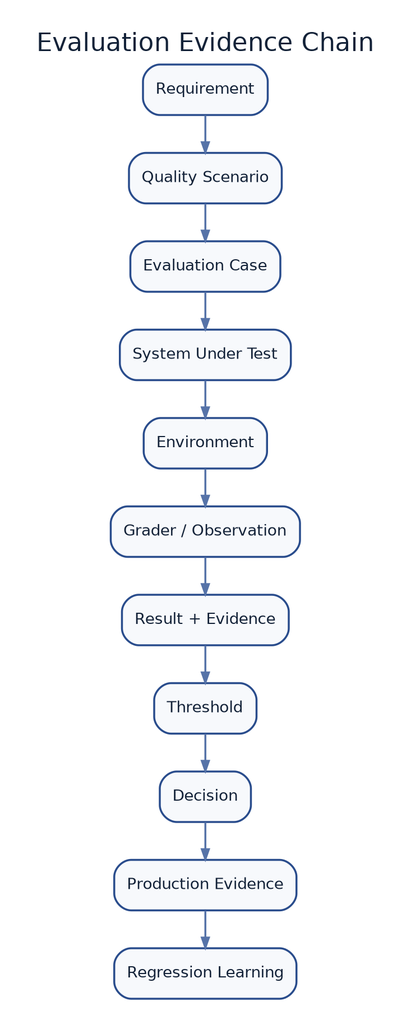

Evaluation Architecture for AI Systems - core architecture figure

**Related chapters:** Chapters 3, 5, 6, 7, and 10

> **An evaluation is not merely a score. It is an evidence-producing system that connects a quality requirement to an architectural decision.**

## 1. Why This Chapter Matters

A team demonstrates an AI assistant to senior stakeholders.

The answers look strong.

A few difficult questions are handled well.

The interface is polished.

Leadership asks:

> Is it ready for production?

The team reports:

- average benchmark score;
- several favourable examples;
- model-provider claims;
- a successful pilot;
- an LLM judge score.

These signals may be useful.

They do not yet establish production fitness.

The real decision may require evidence that:

- the evaluation cases represent the intended workflow;
- high-risk failures are visible;
- the system—not only the model—is being tested;
- the grader measures what stakeholders actually value;
- thresholds reflect consequence;
- results are statistically meaningful;
- changes can be compared reproducibly;
- production behaviour is sampled after release;
- newly discovered failures become regression tests;
- autonomy is reduced when evidence deteriorates.

NIST’s AI Risk Management Framework places measurement throughout the lifecycle and recommends selecting methods according to purpose, audience, context, and significant risks. It calls for defined acceptable limits, pre-deployment and post-deployment assessment, stress testing, independent review where appropriate, real-time monitoring, and documented corrective action.[1]

Current evaluation guidance from OpenAI similarly frames evaluation as a continuous cycle of specifying what good means, measuring under realistic conditions, and improving from observed errors. It distinguishes general model benchmarks from contextual evaluations for a particular workflow.[2]

> **Platform freshness note — 4 September 2026.** OpenAI announced the Evals platform's deprecation on 3 June 2026; existing evals are scheduled to become read-only on 31 October and the Evals dashboard and API to shut down on 30 November 2026.[8] The evaluation architecture in this chapter is deliberately platform-independent: preserve datasets, graders, lineage, evidence, and release decisions outside any retiring control plane.

The central argument of this chapter is:

> **Evaluation must be designed as an architectural capability, not performed as an occasional experiment before launch.**

## 2. Learning Objectives

By the end of this chapter, you should be able to:

- explain why evaluation is part of architecture rather than only testing;
- connect quality scenarios to evaluation cases and release decisions;
- distinguish model, component, workflow, safety, human, production, and outcome evaluations;
- build an evaluation dataset from real tasks, risks, incidents, and edge cases;
- choose deterministic, statistical, model-based, environment-based, or human graders;
- validate an LLM judge rather than assuming it is authoritative;
- define thresholds, confidence intervals, and zero-tolerance invariants;
- prevent leakage, contamination, and evaluator overfitting;
- design offline, integration, shadow, canary, online, and outcome evaluation;
- create release, routing, and autonomy gates;
- maintain lineage for datasets, systems, graders, and results;
- operate a continuous regression-learning loop;
- answer architecture interview questions about evaluation validity, reproducibility, production sampling, and agent testing.

## Part I — Evaluation as Architecture

### 3. What an Evaluation Produces

An evaluation produces more than a number.

A credible evaluation should produce:

- evidence about a defined requirement;
- examples of success and failure;
- uncertainty about the measurement;
- segment-level results;
- known limitations;
- a decision recommendation;
- material for future regression testing.

The evaluation has value only when it informs a decision such as:

- release;
- block;
- rollback;
- route;
- escalate;
- increase review;
- expand autonomy;
- change a model;
- improve retrieval;
- retire a system.

#### Architectural principle — Evaluation serves a decision

> **Every important evaluation should name the decision it is intended to support.**

“Measure answer quality” is incomplete.

“Determine whether version 3 may serve HR policy questions to all employees without mandatory human review” is an architectural evaluation objective.

### 4. The Evaluation Evidence Chain

This handbook uses the following evidence chain:

```
Requirement
   ↓
Quality Scenario
   ↓
Evaluation Case
   ↓
System Under Test
   ↓
Environment
   ↓
Grader or Observation
   ↓
Result + Evidence
   ↓
Threshold
   ↓
Decision
   ↓
Production Evidence
   ↓
Regression Learning
```

This is an original synthesis.

It makes visible several failure points that are often hidden inside an “eval score.”

A high score can still be misleading when:

- the requirement is vague;
- the cases are unrepresentative;
- the environment is unrealistic;
- the grader is invalid;
- the threshold is arbitrary;
- the decision ignores high-risk segments;
- production differs from the test;
- failures are not added back to the suite.

### 5. The Evaluation Contract

An evaluation should have a contract containing:

- **evaluation ID**;
- **decision supported**;
- **quality scenario**;
- **system boundary**;
- **population of interest**;
- **risk segments**;
- **dataset version**;
- **environment version**;
- **system version**;
- **grader version**;
- **metrics**;
- **thresholds**;
- **sampling and repetition**;
- **known limitations**;
- **owner**;
- **expiry or review date**.

Example:

```yaml
evaluation_id: eval_policy_answer_v7
decision:
  allow_release_to_all_uk_employees
quality_scenario:
  grounded_hr_policy_answer
system_under_test:
  retrieval_plus_generation_workflow
population:
  current_uk_hr_questions
segments:
  - common_policy
  - ambiguous_policy
  - conflicting_sources
  - insufficient_evidence
  - high_financial_consequence
dataset_version: hr_gold_2026_08_01
grader_version: policy_rubric_4
thresholds:
  claim_support: ">= 0.98"
  citation_validity: "= 1.00"
  definitive_answer_without_evidence: "= 0"
  p95_latency_seconds: "<= 4"
owner: hr_ai_product_owner
review_by: 2026-09-01
```

The contract helps prevent a result from being reused outside the context it actually supports.

## Part II — Start from Requirements, Not Datasets

### 6. Evaluation Begins with “What Does Good Mean?”

A dataset cannot define success by itself.

The sequence should begin with:

1. business or mission objective;
2. quality attribute scenario;
3. failure and harm analysis;
4. decision to be supported;
5. evaluation cases and graders.

OpenAI’s current evaluation primer recommends defining the workflow, important decision points, desired outputs, and behaviours to avoid with technical and domain experts. It describes a living golden set and an error taxonomy as context-specific assets.[2]

#### Weak starting point

> We found a public benchmark for question answering.

#### Strong starting point

> The assistant must answer current travel-policy questions with supported claims, recognise insufficient evidence, and never treat an advisory response as financial approval.

The stronger statement can produce relevant cases.

### 7. Evaluation Questions

Before building the suite, ask:

- What decision will the result support?
- What is the actual unit of work?
- What failure matters most?
- Which failures are common?
- Which failures are rare but severe?
- Which users or groups could be missed by averages?
- What evidence is available?
- What does appropriate refusal look like?
- Which behaviour is deterministic?
- Which judgment requires domain expertise?
- What production outcome matters?
- When will this evaluation become stale?

### 8. The Unit of Evaluation

Possible units include:

- one response;
- one claim;
- one retrieved passage;
- one tool call;
- one workflow;
- one conversation;
- one completed task;
- one real-world outcome;
- one user session;
- one decision.

The correct unit should match the quality requirement.

A response-level score may miss that:

- the correct tool was never called;
- the wrong record was updated;
- the user needed three retries;
- the final outcome failed;
- a policy breach occurred during an intermediate step.

Agent evaluations increasingly require multi-turn tasks, tools, environments, and state-based grading rather than a single prompt and answer. Anthropic’s current agent-evaluation guidance describes evals as a task plus grading logic, with more complex agent cases judged by the resulting environment and tests.[3]